# Solutions for week 12

Author

Jarkko Toivonen

Published

October 15, 2026

```r
library(tibble)
library(purrr)
library(dplyr)
library(stringr)
library(ggcyto)
library(flowGate)
library(flowWorkspace)
library(Luciernaga)
library(magrittr)
library(openCyto)
library(tidyr)
library(broom)

#source("original_functions.R")

data_path <- file.path("data")
result_path <- file.path("results")

recompute <- FALSE
```

# Problem 1

> In the example above, we deep dived the APC-Fire 810 single-color control. Since this is just one of the 29-single colors in the panel, check the pData, identify a fluorophore and marker of interest and repeat the process detailed above for your selected fluorophore. Report whether your chosen fluorophore behaved similarly or otherwise in terms of fluorescent signature variants as was the case for APC-Fire 810.

## Load data

```r
fcs_files <- list.files(data_path, pattern=".fcs", full.names=TRUE)
fcs_files
```

```
 [1] "data/DTR_2023_ILT_00-Reference Group-4BeadsUnstained (Beads).1237095.fcs"
 [2] "data/DTR_2023_ILT_00-Reference Group-DR_CCR4 BUV615 (Beads).1237096.fcs"
 [3] "data/DTR_2023_ILT_00-Reference Group-DR_CCR6 BV786 (Beads).1237097.fcs"
 [4] "data/DTR_2023_ILT_00-Reference Group-DR_CCR7 BV650 (Beads).1237098.fcs"
 [5] "data/DTR_2023_ILT_00-Reference Group-DR_CD107a APC-R700 (Beads).1237099.fcs"
 [6] "data/DTR_2023_ILT_00-Reference Group-DR_CD127 BV421 (Beads).1237100.fcs"
 [7] "data/DTR_2023_ILT_00-Reference Group-DR_CD16 APC (Beads).1237101.fcs"
 [8] "data/DTR_2023_ILT_00-Reference Group-DR_CD161 BV480 (Beads).1237102.fcs"
 [9] "data/DTR_2023_ILT_00-Reference Group-DR_CD25 PE-Cy5 (Beads).1237103.fcs"
[10] "data/DTR_2023_ILT_00-Reference Group-DR_CD26 PerCP-Cy5.5 (Beads).1237104.fcs"
[11] "data/DTR_2023_ILT_00-Reference Group-DR_CD27 APC-Fire 750 (Beads).1237105.fcs"
[12] "data/DTR_2023_ILT_00-Reference Group-DR_CD3 Alexa Fluor 488 (Beads).1237106.fcs"
[13] "data/DTR_2023_ILT_00-Reference Group-DR_CD3 Alexa Fluor 647 (Beads).1237107.fcs"
[14] "data/DTR_2023_ILT_00-Reference Group-DR_CD3 FITC (Beads).1237108.fcs"
[15] "data/DTR_2023_ILT_00-Reference Group-DR_CD3 Spark Blue 550 (Beads).1237109.fcs"
```

[output cut: 53 more lines]

```r
Bead_FCS <- fcs_files[stringr::str_detect(fcs_files, "Bead")]
Bead_FCS
```

```
 [1] "data/DTR_2023_ILT_00-Reference Group-4BeadsUnstained (Beads).1237095.fcs"
 [2] "data/DTR_2023_ILT_00-Reference Group-DR_CCR4 BUV615 (Beads).1237096.fcs"
 [3] "data/DTR_2023_ILT_00-Reference Group-DR_CCR6 BV786 (Beads).1237097.fcs"
 [4] "data/DTR_2023_ILT_00-Reference Group-DR_CCR7 BV650 (Beads).1237098.fcs"
 [5] "data/DTR_2023_ILT_00-Reference Group-DR_CD107a APC-R700 (Beads).1237099.fcs"
 [6] "data/DTR_2023_ILT_00-Reference Group-DR_CD127 BV421 (Beads).1237100.fcs"
 [7] "data/DTR_2023_ILT_00-Reference Group-DR_CD16 APC (Beads).1237101.fcs"
 [8] "data/DTR_2023_ILT_00-Reference Group-DR_CD161 BV480 (Beads).1237102.fcs"
 [9] "data/DTR_2023_ILT_00-Reference Group-DR_CD25 PE-Cy5 (Beads).1237103.fcs"
[10] "data/DTR_2023_ILT_00-Reference Group-DR_CD26 PerCP-Cy5.5 (Beads).1237104.fcs"
[11] "data/DTR_2023_ILT_00-Reference Group-DR_CD27 APC-Fire 750 (Beads).1237105.fcs"
[12] "data/DTR_2023_ILT_00-Reference Group-DR_CD3 Alexa Fluor 488 (Beads).1237106.fcs"
[13] "data/DTR_2023_ILT_00-Reference Group-DR_CD3 Alexa Fluor 647 (Beads).1237107.fcs"
[14] "data/DTR_2023_ILT_00-Reference Group-DR_CD3 FITC (Beads).1237108.fcs"
[15] "data/DTR_2023_ILT_00-Reference Group-DR_CD3 Spark Blue 550 (Beads).1237109.fcs"
```

[output cut: 18 more lines]

```r
Cell_FCS <- fcs_files[stringr::str_detect(fcs_files, "Cells")]
Cell_FCS
```

```
 [1] "data/DTR_2023_ILT_01-Reference Group-DR_CCR4 BUV615 (Cells).1235678.fcs"
 [2] "data/DTR_2023_ILT_01-Reference Group-DR_CCR6 BV786 (Cells).1235679.fcs"
 [3] "data/DTR_2023_ILT_01-Reference Group-DR_CCR7 BV650 (Cells).1235680.fcs"
 [4] "data/DTR_2023_ILT_01-Reference Group-DR_CD107a APC-R700 (Cells).1235681.fcs"
 [5] "data/DTR_2023_ILT_01-Reference Group-DR_CD127 BV421 (Cells).1235682.fcs"
 [6] "data/DTR_2023_ILT_01-Reference Group-DR_CD16 APC (Cells).1235683.fcs"
 [7] "data/DTR_2023_ILT_01-Reference Group-DR_CD161 BV480 (Cells).1235684.fcs"
 [8] "data/DTR_2023_ILT_01-Reference Group-DR_CD25 PE-Cy5 (Cells).1235685.fcs"
 [9] "data/DTR_2023_ILT_01-Reference Group-DR_CD26 PerCP-Cy5.5 (Cells).1235686.fcs"
[10] "data/DTR_2023_ILT_01-Reference Group-DR_CD27 APC-Fire 750 (Cells).1235687.fcs"
[11] "data/DTR_2023_ILT_01-Reference Group-DR_CD3 Alexa Fluor 488 (Cells).1235688.fcs"
[12] "data/DTR_2023_ILT_01-Reference Group-DR_CD3 Alexa Fluor 647 (Cells).1235689.fcs"
[13] "data/DTR_2023_ILT_01-Reference Group-DR_CD3 FITC (Cells).1235690.fcs"
[14] "data/DTR_2023_ILT_01-Reference Group-DR_CD3 Spark Blue 550 (Cells).1235691.fcs"
[15] "data/DTR_2023_ILT_01-Reference Group-DR_CD38 APC-Fire 810 (Cells).1235692.fcs"
```

[output cut: 17 more lines]

```r
UnstainedCell_FCS <- fcs_files[stringr::str_detect(fcs_files, "_Unstained")]
UnstainedCell_FCS
```

```
[1] "data/DTR_2023_ILT_01-INF052-Ctrl_Unstained.1235650.fcs"
[2] "data/DTR_2023_ILT_01-ND006_v1-Ctrl_Unstained.1235671.fcs"
[3] "data/DTR_2023_ILT_01-ND006_v1-PMA_Unstained.1235672.fcs"
```

Read samples.

```r
Beads_cytoset <- load_cytoset_from_fcs(Bead_FCS, truncate_max_range=FALSE, transformation=FALSE)
BeadsSC_GatingSet <- GatingSet(Beads_cytoset)

Cells_cytoset <- load_cytoset_from_fcs(Cell_FCS, truncate_max_range=FALSE, transformation=FALSE)
CellsSC_GatingSet <- GatingSet(Cells_cytoset)

UnstainedCells_cytoset <- load_cytoset_from_fcs(UnstainedCell_FCS, truncate_max_range=FALSE, transformation=FALSE)
CellsUnstained_GatingSet <- GatingSet(UnstainedCells_cytoset)
```

## Transform data

```r
# Identify biexponential fluorescent detectors, exclude linear ones like FSC

SFC_Parameters <- colnames(CellsUnstained_GatingSet)
FluorophoresOnly <- SFC_Parameters[!stringr::str_detect(SFC_Parameters, "FSC|SSC|Time")]

# Biexponential values that were optimal for this particular instrument/dataset, yours may vary, see Week 7!

Biexponential <-  flowjo_biexp_trans(channelRange=4096, maxValue=4194304,
  pos=5.62, neg=0, widthBasis=-1000)
MyBiexTransform <- transformerList(FluorophoresOnly, Biexponential)
```

Do the transform.

```r
# Beads Single Colors

transform(BeadsSC_GatingSet, MyBiexTransform)
```

```
A GatingSet with 33 samples
```

```r
# Cells Single Colors

transform(CellsSC_GatingSet, MyBiexTransform)
```

```
A GatingSet with 32 samples
```

```r
# Cells Unstained

transform(CellsUnstained_GatingSet, MyBiexTransform)
```

```
A GatingSet with 3 samples
```

## Automated gating

```r
BeadGatingTable <- tibble::tribble(
  ~filterId,    ~dims,                          ~subset,
  "scatter",    list("FSC-A", "SSC-A"),      "root",
  "singlets",   list("FSC-A", "FSC-H"),          "scatter"
)


CellGatingTable <- tibble::tribble(
  ~filterId,    ~dims,                          ~subset,
  "singlets",   list("FSC-A", "FSC-H"),          "root",
  "scatter",    list("FSC-A", "SSC-A"),      "singlets",
)
```

```r
# This version prints the index of specimen, so it is easier to follow
# where we are going.
gs_apply_gate_check2 <- function (gs, gate, sample = NULL, AdjustAll = FALSE, ...)
{
    if (methods::is(gs, "GatingSet")) {
        if (is.null(sample)) {
            Samples <- seq_along(gs)
        }
        else {
            Samples <- sample
        }
        n <- length(Samples)                                 # MODIFIED LINE
        purrr::walk(.x = Samples, .f = function(sample) {
            cat(sprintf("Specimen %i/%i\n", sample, n))      # MODIFIED LINE
            gs_gate_interactive_adjust(gs = gs, gate = gate,
                sample = sample, AdjustAll = AdjustAll, ...)
        })
    }
    else {
        stop("'gs' must be a GatingSet")
    }
}
```

### Beads

Save the result so this can be knitted. For some reason my GatingSet files got corrupted, so I added the backend_opt = “copy” option, even though it should be on by default.

```r
filename <- file.path(result_path, "BeadsSC_GatingSet.gs")
if (! file.exists(filename) || recompute) {
    flowGate::gs_apply_gating_strategy(BeadsSC_GatingSet, gating_strategy = BeadGatingTable)

    gs_apply_gate_check2(gs=BeadsSC_GatingSet, gate="scatter")
    gs_apply_gate_check2(gs=BeadsSC_GatingSet, gate="singlets")

    save_gs(BeadsSC_GatingSet, filename, backend_opt = "copy")
} else {
    BeadsSC_GatingSet <- load_gs(filename)
}
```

### Single-color cells

```r
filename <- file.path(result_path, "CellsSC_GatingSet.gs")
if (! file.exists(filename) || recompute) {
    flowGate::gs_apply_gating_strategy(CellsSC_GatingSet, gating_strategy = CellGatingTable)

    gs_apply_gate_check2(gs=CellsSC_GatingSet, gate="scatter")
    gs_apply_gate_check2(gs=CellsSC_GatingSet, gate="singlets")

    save_gs(CellsSC_GatingSet, filename, backend_opt = "copy")
} else {
    CellsSC_GatingSet <- load_gs(filename)
}
```

Why doesn’t gs_apply_gate_check() function show which speciment it is currently processing? It would be nice, if it would show the specimen name or that x out of y specimen have been checked.

### Unstained

```r
filename <- file.path(result_path, "CellsUnstained_GatingSet.gs")
if (! file.exists(filename) || recompute) {
    flowGate::gs_apply_gating_strategy(CellsUnstained_GatingSet, gating_strategy = CellGatingTable)

    gs_apply_gate_check2(gs=CellsUnstained_GatingSet, gate="scatter")
    gs_apply_gate_check2(gs=CellsUnstained_GatingSet, gate="singlets")

    save_gs(CellsUnstained_GatingSet, filename, backend_opt = "copy")
} else {
    CellsUnstained_GatingSet <- load_gs(filename)
}
```

## Update metadata

### Beads

```r
bead_pd <- pData(BeadsSC_GatingSet)

Updated_bead_pd <- bead_pd |> mutate(
    raw = str_extract(name, "(?<=DR_)[^(]+(?=\\()"),
    Antigen = raw |>
      str_trim() |>
      str_extract("^\\S+"),
    Fluorophore = raw |>
      str_trim() |>
      str_remove("^\\S+\\s+"),
    Type = name |>
      str_extract("(?<=\\()([^)]+)(?=\\))"),
    raw = NULL
  )

Updated_bead_pd <- Updated_bead_pd |> relocate(Fluorophore, Antigen, Type, .after="name")
```

```r
Updated_bead_pd <- Updated_bead_pd |>
  mutate(Fluorophore = case_when(
    Fluorophore == "PE-Vio770" ~ "PE-Vio 770",
    Fluorophore == "PE-Dazzle594" ~ "PE-Dazzle 594",
    TRUE ~ Fluorophore
  ))
```

```r
Updated_bead_pd <- Updated_bead_pd |> mutate(
    Antigen = case_when(
      str_detect(name, "BeadsUnstained") ~ NA_character_,
      .default = Antigen
    ),

    Fluorophore = case_when(
      str_detect(name, "BeadsUnstained") ~ "BeadUnstained",
      .default = Fluorophore
    )
  )
```

```r
pData(BeadsSC_GatingSet) <- Updated_bead_pd
pData(BeadsSC_GatingSet)
```

|  | name | Fluorophore | Antigen | Type |
| --- | --- | --- | --- | --- |
| DTR_2023_ILT_00-Reference Group-4BeadsUnstained (Beads).1237095.fcs | DTR_2023_ILT_00-Reference Group-4BeadsUnstained (Beads).1237095.fcs | BeadUnstained | NA | Beads |
| DTR_2023_ILT_00-Reference Group-DR_CCR4 BUV615 (Beads).1237096.fcs | DTR_2023_ILT_00-Reference Group-DR_CCR4 BUV615 (Beads).1237096.fcs | BUV615 | CCR4 | Beads |
| DTR_2023_ILT_00-Reference Group-DR_CCR6 BV786 (Beads).1237097.fcs | DTR_2023_ILT_00-Reference Group-DR_CCR6 BV786 (Beads).1237097.fcs | BV786 | CCR6 | Beads |
| DTR_2023_ILT_00-Reference Group-DR_CCR7 BV650 (Beads).1237098.fcs | DTR_2023_ILT_00-Reference Group-DR_CCR7 BV650 (Beads).1237098.fcs | BV650 | CCR7 | Beads |
| DTR_2023_ILT_00-Reference Group-DR_CD107a APC-R700 (Beads).1237099.fcs | DTR_2023_ILT_00-Reference Group-DR_CD107a APC-R700 (Beads).1237099.fcs | APC-R700 | CD107a | Beads |
| DTR_2023_ILT_00-Reference Group-DR_CD127 BV421 (Beads).1237100.fcs | DTR_2023_ILT_00-Reference Group-DR_CD127 BV421 (Beads).1237100.fcs | BV421 | CD127 | Beads |
| DTR_2023_ILT_00-Reference Group-DR_CD16 APC (Beads).1237101.fcs | DTR_2023_ILT_00-Reference Group-DR_CD16 APC (Beads).1237101.fcs | APC | CD16 | Beads |
| DTR_2023_ILT_00-Reference Group-DR_CD161 BV480 (Beads).1237102.fcs | DTR_2023_ILT_00-Reference Group-DR_CD161 BV480 (Beads).1237102.fcs | BV480 | CD161 | Beads |
| DTR_2023_ILT_00-Reference Group-DR_CD25 PE-Cy5 (Beads).1237103.fcs | DTR_2023_ILT_00-Reference Group-DR_CD25 PE-Cy5 (Beads).1237103.fcs | PE-Cy5 | CD25 | Beads |
| DTR_2023_ILT_00-Reference Group-DR_CD26 PerCP-Cy5.5 (Beads).1237104.fcs | DTR_2023_ILT_00-Reference Group-DR_CD26 PerCP-Cy5.5 (Beads).1237104.fcs | PerCP-Cy5.5 | CD26 | Beads |
| DTR_2023_ILT_00-Reference Group-DR_CD27 APC-Fire 750 (Beads).1237105.fcs | DTR_2023_ILT_00-Reference Group-DR_CD27 APC-Fire 750 (Beads).1237105.fcs | APC-Fire 750 | CD27 | Beads |
| DTR_2023_ILT_00-Reference Group-DR_CD3 Alexa Fluor 488 (Beads).1237106.fcs | DTR_2023_ILT_00-Reference Group-DR_CD3 Alexa Fluor 488 (Beads).1237106.fcs | Alexa Fluor 488 | CD3 | Beads |
| DTR_2023_ILT_00-Reference Group-DR_CD3 Alexa Fluor 647 (Beads).1237107.fcs | DTR_2023_ILT_00-Reference Group-DR_CD3 Alexa Fluor 647 (Beads).1237107.fcs | Alexa Fluor 647 | CD3 | Beads |
| DTR_2023_ILT_00-Reference Group-DR_CD3 FITC (Beads).1237108.fcs | DTR_2023_ILT_00-Reference Group-DR_CD3 FITC (Beads).1237108.fcs | FITC | CD3 | Beads |
| DTR_2023_ILT_00-Reference Group-DR_CD3 Spark Blue 550 (Beads).1237109.fcs | DTR_2023_ILT_00-Reference Group-DR_CD3 Spark Blue 550 (Beads).1237109.fcs | Spark Blue 550 | CD3 | Beads |
| DTR_2023_ILT_00-Reference Group-DR_CD38 APC-Fire 810 (Beads).1237110.fcs | DTR_2023_ILT_00-Reference Group-DR_CD38 APC-Fire 810 (Beads).1237110.fcs | APC-Fire 810 | CD38 | Beads |
| DTR_2023_ILT_00-Reference Group-DR_CD4 BUV805 (Beads).1237111.fcs | DTR_2023_ILT_00-Reference Group-DR_CD4 BUV805 (Beads).1237111.fcs | BUV805 | CD4 | Beads |
| DTR_2023_ILT_00-Reference Group-DR_CD45RA BV510 (Beads).1237112.fcs | DTR_2023_ILT_00-Reference Group-DR_CD45RA BV510 (Beads).1237112.fcs | BV510 | CD45RA | Beads |
| DTR_2023_ILT_00-Reference Group-DR_CD56 BV605 (Beads).1237113.fcs | DTR_2023_ILT_00-Reference Group-DR_CD56 BV605 (Beads).1237113.fcs | BV605 | CD56 | Beads |
| DTR_2023_ILT_00-Reference Group-DR_CD62L BUV395 (Beads).1237114.fcs | DTR_2023_ILT_00-Reference Group-DR_CD62L BUV395 (Beads).1237114.fcs | BUV395 | CD62L | Beads |
| DTR_2023_ILT_00-Reference Group-DR_CD69 BUV563 (Beads).1237115.fcs | DTR_2023_ILT_00-Reference Group-DR_CD69 BUV563 (Beads).1237115.fcs | BUV563 | CD69 | Beads |
| DTR_2023_ILT_00-Reference Group-DR_CD7 BV711 (Beads).1237116.fcs | DTR_2023_ILT_00-Reference Group-DR_CD7 BV711 (Beads).1237116.fcs | BV711 | CD7 | Beads |
| DTR_2023_ILT_00-Reference Group-DR_CD8 BUV496 (Beads).1237117.fcs | DTR_2023_ILT_00-Reference Group-DR_CD8 BUV496 (Beads).1237117.fcs | BUV496 | CD8 | Beads |
| DTR_2023_ILT_00-Reference Group-DR_CXCR3 BUV737 (Beads).1237118.fcs | DTR_2023_ILT_00-Reference Group-DR_CXCR3 BUV737 (Beads).1237118.fcs | BUV737 | CXCR3 | Beads |
| DTR_2023_ILT_00-Reference Group-DR_Dump_CD14 Pacific Blue (Beads).1237119.fcs | DTR_2023_ILT_00-Reference Group-DR_Dump_CD14 Pacific Blue (Beads).1237119.fcs | Pacific Blue | Dump_CD14 | Beads |
| DTR_2023_ILT_00-Reference Group-DR_Dump_CD19 Pacific Blue (Beads).1237120.fcs | DTR_2023_ILT_00-Reference Group-DR_Dump_CD19 Pacific Blue (Beads).1237120.fcs | Pacific Blue | Dump_CD19 | Beads |
| DTR_2023_ILT_00-Reference Group-DR_IFNg BV750 (Beads).1237121.fcs | DTR_2023_ILT_00-Reference Group-DR_IFNg BV750 (Beads).1237121.fcs | BV750 | IFNg | Beads |
| DTR_2023_ILT_00-Reference Group-DR_NKG2D PE (Beads).1237122.fcs | DTR_2023_ILT_00-Reference Group-DR_NKG2D PE (Beads).1237122.fcs | PE | NKG2D | Beads |
| DTR_2023_ILT_00-Reference Group-DR_PD1 PE-Vio770 (Beads).1237123.fcs | DTR_2023_ILT_00-Reference Group-DR_PD1 PE-Vio770 (Beads).1237123.fcs | PE-Vio 770 | PD1 | Beads |
| DTR_2023_ILT_00-Reference Group-DR_TNFa PE-Dazzle594 (Beads).1237124.fcs | DTR_2023_ILT_00-Reference Group-DR_TNFa PE-Dazzle594 (Beads).1237124.fcs | PE-Dazzle 594 | TNFa | Beads |
| DTR_2023_ILT_00-Reference Group-DR_Va24Ja18 FITC (Beads).1237125.fcs | DTR_2023_ILT_00-Reference Group-DR_Va24Ja18 FITC (Beads).1237125.fcs | FITC | Va24Ja18 | Beads |
| DTR_2023_ILT_00-Reference Group-DR_Va7.2 Alexa Fluor 647 (Beads).1237126.fcs | DTR_2023_ILT_00-Reference Group-DR_Va7.2 Alexa Fluor 647 (Beads).1237126.fcs | Alexa Fluor 647 | Va7.2 | Beads |
| DTR_2023_ILT_00-Reference Group-DR_VD2 BUV661 (Beads).1237127.fcs | DTR_2023_ILT_00-Reference Group-DR_VD2 BUV661 (Beads).1237127.fcs | BUV661 | VD2 | Beads |

```r
filename <- file.path(result_path, "UpdatedBeadMetadata.csv")
write.csv(Updated_bead_pd, filename, row.names=FALSE)
```

### Single-color cells

```r
cell_pd <- pData(CellsSC_GatingSet)

Updated_cell_pd <- cell_pd |> mutate(
    raw = str_extract(name, "(?<=DR_)[^(]+(?=\\()"),
    Antigen = raw |>
      str_trim() |>
      str_extract("^\\S+"),
    Fluorophore = raw |>
      str_trim() |>
      str_remove("^\\S+\\s+"),
    Type = name |>
      str_extract("(?<=\\()([^)]+)(?=\\))"),
    raw = NULL
  )

Updated_cell_pd <- Updated_cell_pd |> relocate(Fluorophore, Antigen, Type, .after="name")

Updated_cell_pd
```

|  | name | Fluorophore | Antigen | Type |
| --- | --- | --- | --- | --- |
| DTR_2023_ILT_01-Reference Group-DR_CCR4 BUV615 (Cells).1235678.fcs | DTR_2023_ILT_01-Reference Group-DR_CCR4 BUV615 (Cells).1235678.fcs | BUV615 | CCR4 | Cells |
| DTR_2023_ILT_01-Reference Group-DR_CCR6 BV786 (Cells).1235679.fcs | DTR_2023_ILT_01-Reference Group-DR_CCR6 BV786 (Cells).1235679.fcs | BV786 | CCR6 | Cells |
| DTR_2023_ILT_01-Reference Group-DR_CCR7 BV650 (Cells).1235680.fcs | DTR_2023_ILT_01-Reference Group-DR_CCR7 BV650 (Cells).1235680.fcs | BV650 | CCR7 | Cells |
| DTR_2023_ILT_01-Reference Group-DR_CD107a APC-R700 (Cells).1235681.fcs | DTR_2023_ILT_01-Reference Group-DR_CD107a APC-R700 (Cells).1235681.fcs | APC-R700 | CD107a | Cells |
| DTR_2023_ILT_01-Reference Group-DR_CD127 BV421 (Cells).1235682.fcs | DTR_2023_ILT_01-Reference Group-DR_CD127 BV421 (Cells).1235682.fcs | BV421 | CD127 | Cells |
| DTR_2023_ILT_01-Reference Group-DR_CD16 APC (Cells).1235683.fcs | DTR_2023_ILT_01-Reference Group-DR_CD16 APC (Cells).1235683.fcs | APC | CD16 | Cells |
| DTR_2023_ILT_01-Reference Group-DR_CD161 BV480 (Cells).1235684.fcs | DTR_2023_ILT_01-Reference Group-DR_CD161 BV480 (Cells).1235684.fcs | BV480 | CD161 | Cells |
| DTR_2023_ILT_01-Reference Group-DR_CD25 PE-Cy5 (Cells).1235685.fcs | DTR_2023_ILT_01-Reference Group-DR_CD25 PE-Cy5 (Cells).1235685.fcs | PE-Cy5 | CD25 | Cells |
| DTR_2023_ILT_01-Reference Group-DR_CD26 PerCP-Cy5.5 (Cells).1235686.fcs | DTR_2023_ILT_01-Reference Group-DR_CD26 PerCP-Cy5.5 (Cells).1235686.fcs | PerCP-Cy5.5 | CD26 | Cells |
| DTR_2023_ILT_01-Reference Group-DR_CD27 APC-Fire 750 (Cells).1235687.fcs | DTR_2023_ILT_01-Reference Group-DR_CD27 APC-Fire 750 (Cells).1235687.fcs | APC-Fire 750 | CD27 | Cells |
| DTR_2023_ILT_01-Reference Group-DR_CD3 Alexa Fluor 488 (Cells).1235688.fcs | DTR_2023_ILT_01-Reference Group-DR_CD3 Alexa Fluor 488 (Cells).1235688.fcs | Alexa Fluor 488 | CD3 | Cells |
| DTR_2023_ILT_01-Reference Group-DR_CD3 Alexa Fluor 647 (Cells).1235689.fcs | DTR_2023_ILT_01-Reference Group-DR_CD3 Alexa Fluor 647 (Cells).1235689.fcs | Alexa Fluor 647 | CD3 | Cells |
| DTR_2023_ILT_01-Reference Group-DR_CD3 FITC (Cells).1235690.fcs | DTR_2023_ILT_01-Reference Group-DR_CD3 FITC (Cells).1235690.fcs | FITC | CD3 | Cells |
| DTR_2023_ILT_01-Reference Group-DR_CD3 Spark Blue 550 (Cells).1235691.fcs | DTR_2023_ILT_01-Reference Group-DR_CD3 Spark Blue 550 (Cells).1235691.fcs | Spark Blue 550 | CD3 | Cells |
| DTR_2023_ILT_01-Reference Group-DR_CD38 APC-Fire 810 (Cells).1235692.fcs | DTR_2023_ILT_01-Reference Group-DR_CD38 APC-Fire 810 (Cells).1235692.fcs | APC-Fire 810 | CD38 | Cells |
| DTR_2023_ILT_01-Reference Group-DR_CD4 BUV805 (Cells).1235693.fcs | DTR_2023_ILT_01-Reference Group-DR_CD4 BUV805 (Cells).1235693.fcs | BUV805 | CD4 | Cells |
| DTR_2023_ILT_01-Reference Group-DR_CD45RA BV510 (Cells).1235694.fcs | DTR_2023_ILT_01-Reference Group-DR_CD45RA BV510 (Cells).1235694.fcs | BV510 | CD45RA | Cells |
| DTR_2023_ILT_01-Reference Group-DR_CD56 BV605 (Cells).1235695.fcs | DTR_2023_ILT_01-Reference Group-DR_CD56 BV605 (Cells).1235695.fcs | BV605 | CD56 | Cells |
| DTR_2023_ILT_01-Reference Group-DR_CD62L BUV395 (Cells).1235696.fcs | DTR_2023_ILT_01-Reference Group-DR_CD62L BUV395 (Cells).1235696.fcs | BUV395 | CD62L | Cells |
| DTR_2023_ILT_01-Reference Group-DR_CD69 BUV563 (Cells).1235697.fcs | DTR_2023_ILT_01-Reference Group-DR_CD69 BUV563 (Cells).1235697.fcs | BUV563 | CD69 | Cells |
| DTR_2023_ILT_01-Reference Group-DR_CD7 BV711 (Cells).1235698.fcs | DTR_2023_ILT_01-Reference Group-DR_CD7 BV711 (Cells).1235698.fcs | BV711 | CD7 | Cells |
| DTR_2023_ILT_01-Reference Group-DR_CD8 BUV496 (Cells).1235699.fcs | DTR_2023_ILT_01-Reference Group-DR_CD8 BUV496 (Cells).1235699.fcs | BUV496 | CD8 | Cells |
| DTR_2023_ILT_01-Reference Group-DR_CXCR3 BUV737 (Cells).1235700.fcs | DTR_2023_ILT_01-Reference Group-DR_CXCR3 BUV737 (Cells).1235700.fcs | BUV737 | CXCR3 | Cells |
| DTR_2023_ILT_01-Reference Group-DR_Dump_CD14 Pacific Blue (Cells).1235701.fcs | DTR_2023_ILT_01-Reference Group-DR_Dump_CD14 Pacific Blue (Cells).1235701.fcs | Pacific Blue | Dump_CD14 | Cells |
| DTR_2023_ILT_01-Reference Group-DR_Dump_CD19 Pacific Blue (Cells).1235702.fcs | DTR_2023_ILT_01-Reference Group-DR_Dump_CD19 Pacific Blue (Cells).1235702.fcs | Pacific Blue | Dump_CD19 | Cells |
| DTR_2023_ILT_01-Reference Group-DR_IFNg BV750 (Cells).1235703.fcs | DTR_2023_ILT_01-Reference Group-DR_IFNg BV750 (Cells).1235703.fcs | BV750 | IFNg | Cells |
| DTR_2023_ILT_01-Reference Group-DR_NKG2D PE (Cells).1235704.fcs | DTR_2023_ILT_01-Reference Group-DR_NKG2D PE (Cells).1235704.fcs | PE | NKG2D | Cells |
| DTR_2023_ILT_01-Reference Group-DR_PD1 PE-Vio770 (Cells).1235705.fcs | DTR_2023_ILT_01-Reference Group-DR_PD1 PE-Vio770 (Cells).1235705.fcs | PE-Vio770 | PD1 | Cells |
| DTR_2023_ILT_01-Reference Group-DR_TNFa PE-Dazzle594 (Cells).1235706.fcs | DTR_2023_ILT_01-Reference Group-DR_TNFa PE-Dazzle594 (Cells).1235706.fcs | PE-Dazzle594 | TNFa | Cells |
| DTR_2023_ILT_01-Reference Group-DR_VD2 BUV661 (Cells).1235707.fcs | DTR_2023_ILT_01-Reference Group-DR_VD2 BUV661 (Cells).1235707.fcs | BUV661 | VD2 | Cells |
| DTR_2023_ILT_01-Reference Group-DR_Viability Zombie NIR (Cells).1235708.fcs | DTR_2023_ILT_01-Reference Group-DR_Viability Zombie NIR (Cells).1235708.fcs | Zombie NIR | Viability | Cells |
| DTR_2023_ILT_01-Reference Group-DR_Viability_PMA Zombie NIR (Cells).1235709.fcs | DTR_2023_ILT_01-Reference Group-DR_Viability_PMA Zombie NIR (Cells).1235709.fcs | Zombie NIR | Viability_PMA | Cells |

```r
Updated_cell_pd <- Updated_cell_pd |>
  mutate(Fluorophore = case_when(
    Fluorophore == "PE-Vio770" ~ "PE-Vio 770",
    Fluorophore == "PE-Dazzle594" ~ "PE-Dazzle 594",
    TRUE ~ Fluorophore
  ))
```

```r
pData(CellsSC_GatingSet) <- Updated_cell_pd
pData(CellsSC_GatingSet)
```

|  | name | Fluorophore | Antigen | Type |
| --- | --- | --- | --- | --- |
| DTR_2023_ILT_01-Reference Group-DR_CCR4 BUV615 (Cells).1235678.fcs | DTR_2023_ILT_01-Reference Group-DR_CCR4 BUV615 (Cells).1235678.fcs | BUV615 | CCR4 | Cells |
| DTR_2023_ILT_01-Reference Group-DR_CCR6 BV786 (Cells).1235679.fcs | DTR_2023_ILT_01-Reference Group-DR_CCR6 BV786 (Cells).1235679.fcs | BV786 | CCR6 | Cells |
| DTR_2023_ILT_01-Reference Group-DR_CCR7 BV650 (Cells).1235680.fcs | DTR_2023_ILT_01-Reference Group-DR_CCR7 BV650 (Cells).1235680.fcs | BV650 | CCR7 | Cells |
| DTR_2023_ILT_01-Reference Group-DR_CD107a APC-R700 (Cells).1235681.fcs | DTR_2023_ILT_01-Reference Group-DR_CD107a APC-R700 (Cells).1235681.fcs | APC-R700 | CD107a | Cells |
| DTR_2023_ILT_01-Reference Group-DR_CD127 BV421 (Cells).1235682.fcs | DTR_2023_ILT_01-Reference Group-DR_CD127 BV421 (Cells).1235682.fcs | BV421 | CD127 | Cells |
| DTR_2023_ILT_01-Reference Group-DR_CD16 APC (Cells).1235683.fcs | DTR_2023_ILT_01-Reference Group-DR_CD16 APC (Cells).1235683.fcs | APC | CD16 | Cells |
| DTR_2023_ILT_01-Reference Group-DR_CD161 BV480 (Cells).1235684.fcs | DTR_2023_ILT_01-Reference Group-DR_CD161 BV480 (Cells).1235684.fcs | BV480 | CD161 | Cells |
| DTR_2023_ILT_01-Reference Group-DR_CD25 PE-Cy5 (Cells).1235685.fcs | DTR_2023_ILT_01-Reference Group-DR_CD25 PE-Cy5 (Cells).1235685.fcs | PE-Cy5 | CD25 | Cells |
| DTR_2023_ILT_01-Reference Group-DR_CD26 PerCP-Cy5.5 (Cells).1235686.fcs | DTR_2023_ILT_01-Reference Group-DR_CD26 PerCP-Cy5.5 (Cells).1235686.fcs | PerCP-Cy5.5 | CD26 | Cells |
| DTR_2023_ILT_01-Reference Group-DR_CD27 APC-Fire 750 (Cells).1235687.fcs | DTR_2023_ILT_01-Reference Group-DR_CD27 APC-Fire 750 (Cells).1235687.fcs | APC-Fire 750 | CD27 | Cells |
| DTR_2023_ILT_01-Reference Group-DR_CD3 Alexa Fluor 488 (Cells).1235688.fcs | DTR_2023_ILT_01-Reference Group-DR_CD3 Alexa Fluor 488 (Cells).1235688.fcs | Alexa Fluor 488 | CD3 | Cells |
| DTR_2023_ILT_01-Reference Group-DR_CD3 Alexa Fluor 647 (Cells).1235689.fcs | DTR_2023_ILT_01-Reference Group-DR_CD3 Alexa Fluor 647 (Cells).1235689.fcs | Alexa Fluor 647 | CD3 | Cells |
| DTR_2023_ILT_01-Reference Group-DR_CD3 FITC (Cells).1235690.fcs | DTR_2023_ILT_01-Reference Group-DR_CD3 FITC (Cells).1235690.fcs | FITC | CD3 | Cells |
| DTR_2023_ILT_01-Reference Group-DR_CD3 Spark Blue 550 (Cells).1235691.fcs | DTR_2023_ILT_01-Reference Group-DR_CD3 Spark Blue 550 (Cells).1235691.fcs | Spark Blue 550 | CD3 | Cells |
| DTR_2023_ILT_01-Reference Group-DR_CD38 APC-Fire 810 (Cells).1235692.fcs | DTR_2023_ILT_01-Reference Group-DR_CD38 APC-Fire 810 (Cells).1235692.fcs | APC-Fire 810 | CD38 | Cells |
| DTR_2023_ILT_01-Reference Group-DR_CD4 BUV805 (Cells).1235693.fcs | DTR_2023_ILT_01-Reference Group-DR_CD4 BUV805 (Cells).1235693.fcs | BUV805 | CD4 | Cells |
| DTR_2023_ILT_01-Reference Group-DR_CD45RA BV510 (Cells).1235694.fcs | DTR_2023_ILT_01-Reference Group-DR_CD45RA BV510 (Cells).1235694.fcs | BV510 | CD45RA | Cells |
| DTR_2023_ILT_01-Reference Group-DR_CD56 BV605 (Cells).1235695.fcs | DTR_2023_ILT_01-Reference Group-DR_CD56 BV605 (Cells).1235695.fcs | BV605 | CD56 | Cells |
| DTR_2023_ILT_01-Reference Group-DR_CD62L BUV395 (Cells).1235696.fcs | DTR_2023_ILT_01-Reference Group-DR_CD62L BUV395 (Cells).1235696.fcs | BUV395 | CD62L | Cells |
| DTR_2023_ILT_01-Reference Group-DR_CD69 BUV563 (Cells).1235697.fcs | DTR_2023_ILT_01-Reference Group-DR_CD69 BUV563 (Cells).1235697.fcs | BUV563 | CD69 | Cells |
| DTR_2023_ILT_01-Reference Group-DR_CD7 BV711 (Cells).1235698.fcs | DTR_2023_ILT_01-Reference Group-DR_CD7 BV711 (Cells).1235698.fcs | BV711 | CD7 | Cells |
| DTR_2023_ILT_01-Reference Group-DR_CD8 BUV496 (Cells).1235699.fcs | DTR_2023_ILT_01-Reference Group-DR_CD8 BUV496 (Cells).1235699.fcs | BUV496 | CD8 | Cells |
| DTR_2023_ILT_01-Reference Group-DR_CXCR3 BUV737 (Cells).1235700.fcs | DTR_2023_ILT_01-Reference Group-DR_CXCR3 BUV737 (Cells).1235700.fcs | BUV737 | CXCR3 | Cells |
| DTR_2023_ILT_01-Reference Group-DR_Dump_CD14 Pacific Blue (Cells).1235701.fcs | DTR_2023_ILT_01-Reference Group-DR_Dump_CD14 Pacific Blue (Cells).1235701.fcs | Pacific Blue | Dump_CD14 | Cells |
| DTR_2023_ILT_01-Reference Group-DR_Dump_CD19 Pacific Blue (Cells).1235702.fcs | DTR_2023_ILT_01-Reference Group-DR_Dump_CD19 Pacific Blue (Cells).1235702.fcs | Pacific Blue | Dump_CD19 | Cells |
| DTR_2023_ILT_01-Reference Group-DR_IFNg BV750 (Cells).1235703.fcs | DTR_2023_ILT_01-Reference Group-DR_IFNg BV750 (Cells).1235703.fcs | BV750 | IFNg | Cells |
| DTR_2023_ILT_01-Reference Group-DR_NKG2D PE (Cells).1235704.fcs | DTR_2023_ILT_01-Reference Group-DR_NKG2D PE (Cells).1235704.fcs | PE | NKG2D | Cells |
| DTR_2023_ILT_01-Reference Group-DR_PD1 PE-Vio770 (Cells).1235705.fcs | DTR_2023_ILT_01-Reference Group-DR_PD1 PE-Vio770 (Cells).1235705.fcs | PE-Vio 770 | PD1 | Cells |
| DTR_2023_ILT_01-Reference Group-DR_TNFa PE-Dazzle594 (Cells).1235706.fcs | DTR_2023_ILT_01-Reference Group-DR_TNFa PE-Dazzle594 (Cells).1235706.fcs | PE-Dazzle 594 | TNFa | Cells |
| DTR_2023_ILT_01-Reference Group-DR_VD2 BUV661 (Cells).1235707.fcs | DTR_2023_ILT_01-Reference Group-DR_VD2 BUV661 (Cells).1235707.fcs | BUV661 | VD2 | Cells |
| DTR_2023_ILT_01-Reference Group-DR_Viability Zombie NIR (Cells).1235708.fcs | DTR_2023_ILT_01-Reference Group-DR_Viability Zombie NIR (Cells).1235708.fcs | Zombie NIR | Viability | Cells |
| DTR_2023_ILT_01-Reference Group-DR_Viability_PMA Zombie NIR (Cells).1235709.fcs | DTR_2023_ILT_01-Reference Group-DR_Viability_PMA Zombie NIR (Cells).1235709.fcs | Zombie NIR | Viability_PMA | Cells |

```r
filename <- file.path(result_path, "InitialCellMetadata.csv")
write.csv(Updated_cell_pd, filename, row.names=FALSE)
```

Check the results.

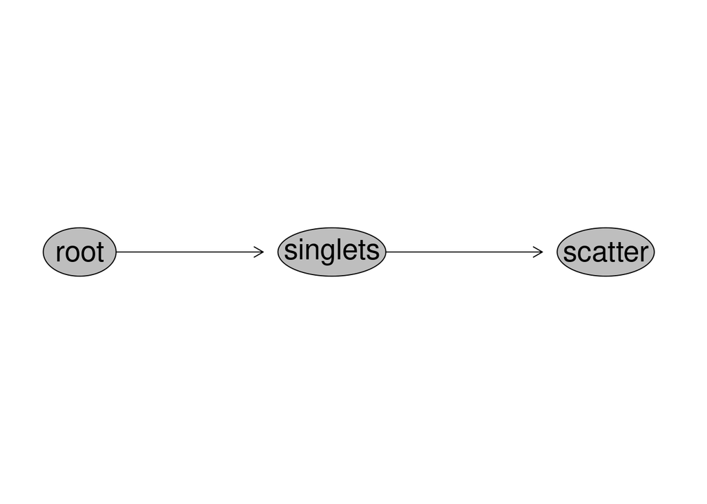

```r
plot(CellsSC_GatingSet)
```

## Alexa Fluor 647 GatingSet

I chose Alexa Fluor 647 as the color.

```r
Alexa_GS <- subset(CellsSC_GatingSet, Fluorophore == "Alexa Fluor 647", realize_view == TRUE)

Alexa_GS
```

```
A GatingSet with 1 samples
```

```r
Plots <- Luciernaga::QC_ReferenceLibrary(FluorNameContains="Alexa Fluor 647", returnPlots=TRUE, NumberDetectors=64) #5-laser Aurora #64 detectors
plotly::ggplotly(Plots[[2]])
```

[interactive chart not shown]

Looks like we need the R2 detector.

```r
Alexa_GS %>% colnames() %>% sort()
```

```
 [1] "B1-A"    "B10-A"   "B11-A"   "B12-A"   "B13-A"   "B14-A"   "B2-A"
 [8] "B3-A"    "B4-A"    "B5-A"    "B6-A"    "B7-A"    "B8-A"    "B9-A"
[15] "FSC-A"   "FSC-H"   "FSC-W"   "R1-A"    "R2-A"    "R3-A"    "R4-A"
[22] "R5-A"    "R6-A"    "R7-A"    "R8-A"    "SSC-A"   "SSC-B-A" "SSC-B-H"
[29] "SSC-B-W" "SSC-H"   "SSC-W"   "Time"    "UV1-A"   "UV10-A"  "UV11-A"
[36] "UV12-A"  "UV13-A"  "UV14-A"  "UV15-A"  "UV16-A"  "UV2-A"   "UV3-A"
[43] "UV4-A"   "UV5-A"   "UV6-A"   "UV7-A"   "UV8-A"   "UV9-A"   "V1-A"
[50] "V10-A"   "V11-A"   "V12-A"   "V13-A"   "V14-A"   "V15-A"   "V16-A"
[57] "V2-A"    "V3-A"    "V4-A"    "V5-A"    "V6-A"    "V7-A"    "V8-A"
[64] "V9-A"    "YG1-A"   "YG10-A"  "YG2-A"   "YG3-A"   "YG4-A"   "YG5-A"
[71] "YG6-A"   "YG7-A"   "YG8-A"   "YG9-A"
```

R2-A to be precise.

Draw the gates for the color and the internal negative.

```r
alexa_filename <- file.path(result_path, "Alexa.gs")
if (! file.exists(alexa_filename) || recompute) {
  flowGate::gs_gate_interactive(gs=Alexa_GS, filterId="Alexa", sample=1,
    dims=list("R2-A"), subset="scatter")
  plot(Alexa_GS)
  flowGate::gs_gate_interactive(gs=Alexa_GS, filterId="InternalNegative", sample=1,
    dims=list("R2-A"), subset="scatter")
  save_gs(Alexa_GS, alexa_filename, backend_opt = "copy")
} else {
  Alexa_GS <- load_gs(alexa_filename)
}
```

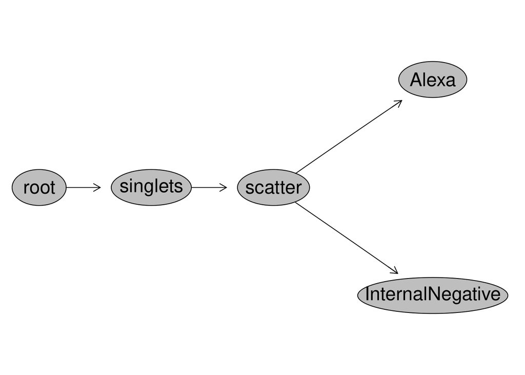

```r
plot(Alexa_GS)
```

Show the gates.

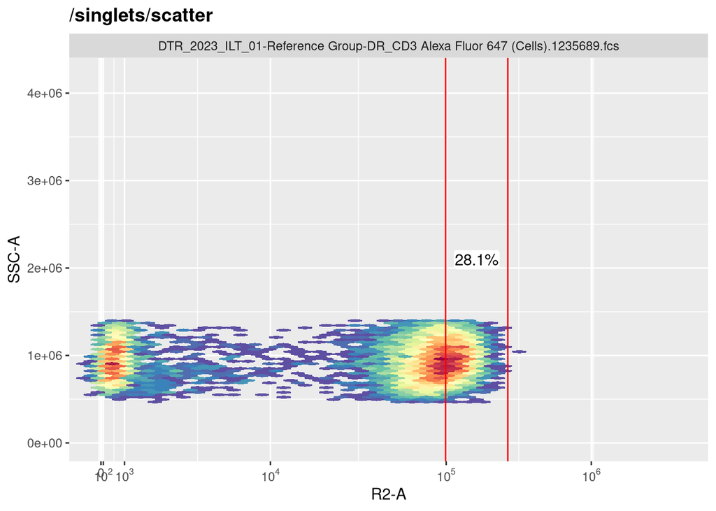

```r
autoplot(Alexa_GS, "Alexa")
```

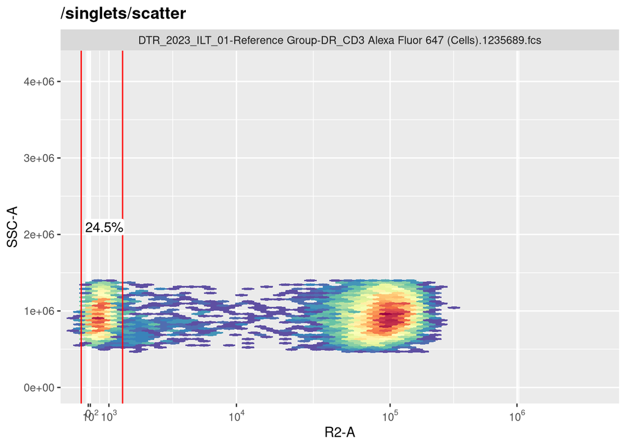

```r
autoplot(Alexa_GS, "InternalNegative")
```

## Positive data

```r
PositiveCytoSet <- gs_pop_get_data(Alexa_GS, "Alexa", inverse.transform=TRUE)
PositiveMatrix <- exprs(PositiveCytoSet[[1]]) #[[1]] used to remove list item, allowing access
PositiveData <- data.frame(PositiveMatrix, check.names=FALSE)
head(PositiveData, 3)
```

| Time | UV1-A | UV2-A | UV3-A | UV4-A | UV5-A | UV6-A | UV7-A | UV8-A | UV9-A | UV10-A | UV11-A | UV12-A | UV13-A | UV14-A | UV15-A | UV16-A | SSC-W | SSC-H | SSC-A | V1-A | V2-A | V3-A | V4-A | V5-A | V6-A | V7-A | V8-A | V9-A | V10-A | … |
| --- | --- | --- | --- | --- | --- | --- | --- | --- | --- | --- | --- | --- | --- | --- | --- | --- | --- | --- | --- | --- | --- | --- | --- | --- | --- | --- | --- | --- | --- | --- |
| 466605 | 340.8606 | 14.28034 | 75.93701 | 528.65753 | 907.4498 | 1560.685 | 3678.291 | 2450.508 | 3209.504 | 952.0745 | 698.4559 | 762.8640 | 948.9510 | 749.6999 | 580.8688 | -224.3149 | 664417.8 | 828752 | 917729.2 | 11.89349 | 1730.300 | 3412.819 | 3457.644 | 5291.069 | 4945.875 | 6641.456 | 5413.375 | 3331.419 | 4345.894 | … |
| 495528 | 192.7054 | 544.64844 | 931.84424 | 169.87248 | 1007.6329 | 1525.357 | 3897.473 | 2886.048 | 2438.682 | 659.0370 | 781.4578 | 185.7886 | 913.7712 | 809.0511 | 231.8267 | 527.9139 | 689720.2 | 891257 | 1024529.9 | 991.78705 | 2336.400 | 4366.862 | 4581.913 | 6385.843 | 6529.188 | 8414.175 | 5725.294 | 4548.500 | 4913.013 | … |
| 217203 | 803.4736 | 1309.22290 | 592.47137 | 73.48249 | 1062.2234 | 1272.036 | 3944.031 | 2592.489 | 3602.577 | 912.3581 | 938.0177 | 480.5366 | 407.4265 | 723.4462 | 1027.5651 | 319.2922 | 666391.8 | 814675 | 904821.2 | 427.41913 | 2436.981 | 3715.938 | 4060.856 | 6925.325 | 6211.356 | 9292.388 | 7313.143 | 5283.988 | 6380.688 | … |

```r
summary(PositiveData)
```

```
      Time            UV1-A             UV2-A            UV3-A
 Min.   :     7   Min.   :-832.40   Min.   :-452.6   Min.   :-426.8
 1st Qu.:152447   1st Qu.:  70.51   1st Qu.: 343.0   1st Qu.: 327.8
 Median :289709   Median : 300.48   Median : 572.5   Median : 537.6
 Mean   :292012   Mean   : 303.93   Mean   : 568.7   Mean   : 535.7
 3rd Qu.:432268   3rd Qu.: 536.62   3rd Qu.: 786.5   3rd Qu.: 733.1
 Max.   :584295   Max.   :1368.43   Max.   :2047.2   Max.   :1490.5
     UV4-A            UV5-A            UV6-A            UV7-A
 Min.   :-311.8   Min.   :-265.1   Min.   : 277.7   Min.   : 1439
 1st Qu.: 446.3   1st Qu.: 749.2   1st Qu.:1415.1   1st Qu.: 3044
 Median : 655.2   Median : 989.2   Median :1719.5   Median : 3625
 Mean   : 663.8   Mean   : 996.8   Mean   :1756.1   Mean   : 3821
 3rd Qu.: 869.4   3rd Qu.:1240.2   3rd Qu.:2052.8   3rd Qu.: 4367
 Max.   :1801.6   Max.   :2160.7   Max.   :4518.1   Max.   :12796
     UV8-A            UV9-A            UV10-A           UV11-A
 Min.   : 848.5   Min.   : 806.1   Min.   :-178.6   Min.   :-201.3
 1st Qu.:2301.3   1st Qu.:2178.5   1st Qu.: 866.5   1st Qu.: 972.0
 Median :2763.8   Median :2649.2   Median :1130.6   Median :1203.3
 Mean   :2923.3   Mean   :2774.6   Mean   :1179.0   Mean   :1215.2
 3rd Qu.:3348.6   3rd Qu.:3205.9   3rd Qu.:1442.4   3rd Qu.:1452.6
 Max.   :9508.0   Max.   :9483.6   Max.   :3687.3   Max.   :3016.8
     UV12-A           UV13-A           UV14-A           UV15-A
 Min.   :-120.9   Min.   :-527.3   Min.   :-300.8   Min.   :-638.6
 1st Qu.: 626.3   1st Qu.: 419.7   1st Qu.: 485.3   1st Qu.: 272.8
 Median : 834.8   Median : 631.3   Median : 721.4   Median : 502.6
 Mean   : 840.4   Mean   : 642.5   Mean   : 717.6   Mean   : 506.7
 3rd Qu.:1045.7   3rd Qu.: 847.0   3rd Qu.: 939.7   3rd Qu.: 738.5
 Max.   :2057.4   Max.   :1678.9   Max.   :2085.3   Max.   :1566.6
     UV16-A           SSC-W            SSC-H             SSC-A
 Min.   :-624.3   Min.   :606522   Min.   : 420383   Min.   : 457027
 1st Qu.: 161.4   1st Qu.:659215   1st Qu.: 750186   1st Qu.: 841944
 Median : 389.4   Median :673978   Median : 860486   Median : 969220
 Mean   : 385.5   Mean   :677109   Mean   : 861818   Mean   : 972247
 3rd Qu.: 600.4   3rd Qu.:690423   3rd Qu.: 975270   3rd Qu.:1101418
 Max.   :1397.4   Max.   :904172   Max.   :1298882   Max.   :1403486
      V1-A             V2-A             V3-A           V4-A
 Min.   :-353.0   Min.   : 585.5   Min.   :1107   Min.   : 1578
 1st Qu.: 401.8   1st Qu.:1772.4   1st Qu.:3001   1st Qu.: 3532
 Median : 602.0   Median :2114.0   Median :3558   Median : 4118
 Mean   : 606.4   Mean   :2165.9   Mean   :3672   Mean   : 4249
```

[output cut: 78 more lines]

```
 Max.   :3103.7   Max.   :144222   Max.   :248372   Max.   :176548
      R4-A             R5-A            R6-A            R7-A
 Min.   : 40922   Min.   :33636   Min.   :20645   Min.   :15656
 1st Qu.: 46595   1st Qu.:38770   1st Qu.:23756   1st Qu.:18458
 Median : 51611   Median :43034   Median :26281   Median :20465
 Mean   : 54116   Mean   :45130   Mean   :27607   Mean   :21447
 3rd Qu.: 59232   3rd Qu.:49433   3rd Qu.:30293   3rd Qu.:23469
 Max.   :105904   Max.   :88411   Max.   :53979   Max.   :42214
      R8-A
 Min.   : 6427
 1st Qu.: 8195
 Median : 9088
 Mean   : 9520
 3rd Qu.:10486
 Max.   :18674
```

## Negative data

```r
NegativeCytoSet <- gs_pop_get_data(Alexa_GS, "InternalNegative", inverse.transform=TRUE)
NegativeMatrix <- exprs(NegativeCytoSet[[1]]) #[[1]] used to remove list item, allowing access
NegativeData <- data.frame(NegativeMatrix, check.names=FALSE)
head(NegativeData, 3)
```

| Time | UV1-A | UV2-A | UV3-A | UV4-A | UV5-A | UV6-A | UV7-A | UV8-A | UV9-A | UV10-A | UV11-A | UV12-A | UV13-A | UV14-A | UV15-A | UV16-A | SSC-W | SSC-H | SSC-A | V1-A | V2-A | V3-A | V4-A | V5-A | V6-A | V7-A | V8-A | V9-A | V10-A | … |
| --- | --- | --- | --- | --- | --- | --- | --- | --- | --- | --- | --- | --- | --- | --- | --- | --- | --- | --- | --- | --- | --- | --- | --- | --- | --- | --- | --- | --- | --- | --- |
| 262045 | -270.20398 | -44.99736 | 335.1334 | 394.7083 | 250.5694 | 1010.087 | 1746.920 | 1625.763 | 1771.835 | 1385.2346 | 589.7935 | 258.0814 | 180.0619 | 335.580444 | 544.6484 | 35.92291 | 627289.0 | 659658 | 689660.4 | -210.7186 | 1013.237 | 1672.068 | 2443.788 | 4074.057 | 3638.457 | 5199.287 | 4911.431 | 3474.969 | 3557.469 | … |
| 198262 | 59.35086 | 725.90015 | 860.6677 | 515.6415 | 511.9234 | 1383.821 | 2553.591 | 1650.828 | 2439.500 | 638.0629 | 728.3542 | 352.6120 | 357.5948 | 585.926209 | -199.0279 | -226.76982 | 652639.9 | 967123 | 1051971.8 | 357.4309 | 1919.431 | 2845.012 | 3757.394 | 5544.550 | 5275.050 | 6881.532 | 4633.063 | 3171.232 | 3805.450 | … |
| 358085 | 136.25529 | 652.56610 | 745.5350 | 1083.5699 | 1628.7384 | 1701.105 | 3239.255 | 2501.827 | 2770.840 | 1048.7622 | 726.4203 | -221.7865 | 225.7285 | -5.206184 | 556.3250 | 419.32617 | 659330.8 | 757693 | 832617.2 | 751.4379 | 2410.719 | 2782.381 | 3659.906 | 5782.356 | 5490.719 | 7267.356 | 5499.381 | 4716.869 | 4532.757 | … |

```r
summary(NegativeData)
```

```
      Time            UV1-A             UV2-A            UV3-A
 Min.   :    22   Min.   :-909.01   Min.   :-580.4   Min.   :-610.6
 1st Qu.:153183   1st Qu.:  85.75   1st Qu.: 345.8   1st Qu.: 317.9
 Median :296472   Median : 307.91   Median : 565.9   Median : 522.5
 Mean   :293256   Mean   : 302.83   Mean   : 581.4   Mean   : 527.0
 3rd Qu.:430457   3rd Qu.: 530.26   3rd Qu.: 810.4   3rd Qu.: 739.5
 Max.   :583367   Max.   :1403.68   Max.   :1725.4   Max.   :1512.9
     UV4-A            UV5-A             UV6-A            UV7-A
 Min.   :-260.8   Min.   :  22.98   Min.   : 133.9   Min.   :1431
 1st Qu.: 441.9   1st Qu.: 712.66   1st Qu.:1278.7   1st Qu.:2749
 Median : 639.6   Median : 955.38   Median :1576.0   Median :3322
 Mean   : 647.6   Mean   : 964.52   Mean   :1622.6   Mean   :3421
 3rd Qu.: 862.1   3rd Qu.:1196.42   3rd Qu.:1957.9   3rd Qu.:4015
 Max.   :1916.6   Max.   :2596.58   Max.   :3312.3   Max.   :7698
     UV8-A            UV9-A            UV10-A            UV11-A
 Min.   : 408.2   Min.   : 744.5   Min.   : -76.68   Min.   :-387.3
 1st Qu.:2065.0   1st Qu.:1992.7   1st Qu.: 793.02   1st Qu.: 419.9
 Median :2494.6   Median :2408.9   Median :1031.99   Median : 659.4
 Mean   :2573.7   Mean   :2462.2   Mean   :1049.04   Mean   : 647.1
 3rd Qu.:3020.1   3rd Qu.:2898.3   3rd Qu.:1298.83   3rd Qu.: 855.5
 Max.   :5116.0   Max.   :6108.9   Max.   :2402.24   Max.   :1772.3
     UV12-A           UV13-A           UV14-A           UV15-A
 Min.   :-590.2   Min.   :-799.4   Min.   :-599.8   Min.   :-744.79
 1st Qu.: 191.9   1st Qu.: 123.7   1st Qu.: 166.2   1st Qu.:  85.12
 Median : 399.7   Median : 316.2   Median : 394.3   Median : 304.64
 Mean   : 394.5   Mean   : 321.5   Mean   : 389.6   Mean   : 306.24
 3rd Qu.: 587.0   3rd Qu.: 504.6   3rd Qu.: 604.6   3rd Qu.: 525.55
 Max.   :1525.3   Max.   :1299.3   Max.   :1429.8   Max.   :1390.44
     UV16-A            SSC-W            SSC-H             SSC-A
 Min.   :-807.12   Min.   :615200   Min.   : 447186   Min.   : 488437
 1st Qu.:  29.79   1st Qu.:654321   1st Qu.: 719852   1st Qu.: 802979
 Median : 244.02   Median :668097   Median : 834668   Median : 937543
 Mean   : 255.29   Mean   :672759   Mean   : 845558   Mean   : 947951
 3rd Qu.: 476.50   3rd Qu.:686531   3rd Qu.: 968557   3rd Qu.:1085494
 Max.   :1280.29   Max.   :893454   Max.   :1294216   Max.   :1399701
      V1-A             V2-A              V3-A           V4-A
 Min.   :-401.9   Min.   : -18.36   Min.   :1089   Min.   : 1494
 1st Qu.: 385.8   1st Qu.:1648.33   1st Qu.:2832   1st Qu.: 3267
 Median : 591.7   Median :2032.97   Median :3413   Median : 3996
 Mean   : 599.9   Mean   :2136.68   Mean   :3642   Mean   : 4224
```

[output cut: 78 more lines]

```
 Max.   :1325.24   Max.   :1664.0   Max.   :1673.4   Max.   :1944.2
      R4-A             R5-A             R6-A              R7-A
 Min.   :-671.1   Min.   :-585.5   Min.   :-670.46   Min.   :-816.3
 1st Qu.: 268.7   1st Qu.: 152.3   1st Qu.:  75.06   1st Qu.:  47.3
 Median : 499.9   Median : 344.2   Median : 266.74   Median : 250.5
 Mean   : 502.4   Mean   : 352.7   Mean   : 266.03   Mean   : 250.0
 3rd Qu.: 729.2   3rd Qu.: 552.2   3rd Qu.: 458.25   3rd Qu.: 471.4
 Max.   :1780.2   Max.   :1769.7   Max.   :1233.61   Max.   :1525.8
      R8-A
 Min.   :-864.22
 1st Qu.: -52.71
 Median : 165.20
 Mean   : 151.72
 3rd Qu.: 358.45
 Max.   :1295.84
```

## Positive signature

```r
SFC_Parameters <- colnames(PositiveData)
PositiveDataSignature <- PositiveData[!stringr::str_detect(colnames(PositiveData), "FSC|SSC|Time")]

head(PositiveDataSignature, 3)
```

| UV1-A | UV2-A | UV3-A | UV4-A | UV5-A | UV6-A | UV7-A | UV8-A | UV9-A | UV10-A | UV11-A | UV12-A | UV13-A | UV14-A | UV15-A | UV16-A | V1-A | V2-A | V3-A | V4-A | V5-A | V6-A | V7-A | V8-A | V9-A | V10-A | V11-A | V12-A | V13-A | V14-A | … |
| --- | --- | --- | --- | --- | --- | --- | --- | --- | --- | --- | --- | --- | --- | --- | --- | --- | --- | --- | --- | --- | --- | --- | --- | --- | --- | --- | --- | --- | --- | --- |
| 340.8606 | 14.28034 | 75.93701 | 528.65753 | 907.4498 | 1560.685 | 3678.291 | 2450.508 | 3209.504 | 952.0745 | 698.4559 | 762.8640 | 948.9510 | 749.6999 | 580.8688 | -224.3149 | 11.89349 | 1730.300 | 3412.819 | 3457.644 | 5291.069 | 4945.875 | 6641.456 | 5413.375 | 3331.419 | 4345.894 | 3327.707 | 2363.969 | 1616.931 | 1677.156 | … |
| 192.7054 | 544.64844 | 931.84424 | 169.87248 | 1007.6329 | 1525.357 | 3897.473 | 2886.048 | 2438.682 | 659.0370 | 781.4578 | 185.7886 | 913.7712 | 809.0511 | 231.8267 | 527.9139 | 991.78705 | 2336.400 | 4366.862 | 4581.913 | 6385.843 | 6529.188 | 8414.175 | 5725.294 | 4548.500 | 4913.013 | 3019.500 | 1862.231 | 1800.012 | 1724.526 | … |
| 803.4736 | 1309.22290 | 592.47137 | 73.48249 | 1062.2234 | 1272.036 | 3944.031 | 2592.489 | 3602.577 | 912.3581 | 938.0177 | 480.5366 | 407.4265 | 723.4462 | 1027.5651 | 319.2922 | 427.41913 | 2436.981 | 3715.938 | 4060.856 | 6925.325 | 6211.356 | 9292.388 | 7313.143 | 5283.988 | 6380.688 | 4041.194 | 2539.901 | 1746.731 | 1891.313 | … |

```r
PositiveSignature <- PositiveDataSignature |> summarize_all("median") #Alternate: "mean"
PositiveSignature
```

| UV1-A | UV2-A | UV3-A | UV4-A | UV5-A | UV6-A | UV7-A | UV8-A | UV9-A | UV10-A | UV11-A | UV12-A | UV13-A | UV14-A | UV15-A | UV16-A | V1-A | V2-A | V3-A | V4-A | V5-A | V6-A | V7-A | V8-A | V9-A | V10-A | V11-A | V12-A | V13-A | V14-A | … |
| --- | --- | --- | --- | --- | --- | --- | --- | --- | --- | --- | --- | --- | --- | --- | --- | --- | --- | --- | --- | --- | --- | --- | --- | --- | --- | --- | --- | --- | --- | --- |
| 300.4754 | 572.4642 | 537.5829 | 655.1697 | 989.1877 | 1719.55 | 3625.409 | 2763.775 | 2649.163 | 1130.649 | 1203.313 | 834.7855 | 631.295 | 721.3636 | 502.5521 | 389.4276 | 601.9755 | 2113.994 | 3557.744 | 4118.332 | 6135.524 | 5843.337 | 8034.745 | 6152.645 | 4432.519 | 5206.918 | 3623.057 | 2222.757 | 1988.388 | 1769.006 | … |

```r
PositivePlotData <- PositiveSignature |> mutate(Fluorophore="Alexa") |> relocate(Fluorophore, .before=1)

Plots <- VisualizeSignatures(data=PositivePlotData, columnname="Fluorophore", Normalize = FALSE)
plotly::ggplotly(Plots)
```

[interactive chart not shown]

```r
Outputs <- QC_WhatsThis(x="Alexa", columnname="Fluorophore", data=PositivePlotData, NumberDetectors = 64,
 returnPlots=TRUE, NumberHits = 5)
```

```
Normalizing Data for Signature Comparison
```

```r
Outputs[[1]]
```

| Fluorophore | ID_Alexa |
| --- | --- |
| Alexa Fluor 647 | 0.99 |
| APC-Cy5 | 0.99 |
| CF647 | 0.99 |
| cFluor R668 | 0.99 |
| Cy5 | 0.99 |

```r
plotly::ggplotly(Outputs[[2]])
```

[interactive chart not shown]

Otherwise very similary except for the autofluorescence.

## Negative signature

```r
NegativeDataSignature <- NegativeData[!stringr::str_detect(colnames(NegativeData), "FSC|SSC|Time")]

head(NegativeDataSignature, 3)
```

| UV1-A | UV2-A | UV3-A | UV4-A | UV5-A | UV6-A | UV7-A | UV8-A | UV9-A | UV10-A | UV11-A | UV12-A | UV13-A | UV14-A | UV15-A | UV16-A | V1-A | V2-A | V3-A | V4-A | V5-A | V6-A | V7-A | V8-A | V9-A | V10-A | V11-A | V12-A | V13-A | V14-A | … |
| --- | --- | --- | --- | --- | --- | --- | --- | --- | --- | --- | --- | --- | --- | --- | --- | --- | --- | --- | --- | --- | --- | --- | --- | --- | --- | --- | --- | --- | --- | --- |
| -270.20398 | -44.99736 | 335.1334 | 394.7083 | 250.5694 | 1010.087 | 1746.920 | 1625.763 | 1771.835 | 1385.2346 | 589.7935 | 258.0814 | 180.0619 | 335.580444 | 544.6484 | 35.92291 | -210.7186 | 1013.237 | 1672.068 | 2443.788 | 4074.057 | 3638.457 | 5199.287 | 4911.431 | 3474.969 | 3557.469 | 1848.963 | 868.0378 | 594.8934 | 1017.2938 | … |
| 59.35086 | 725.90015 | 860.6677 | 515.6415 | 511.9234 | 1383.821 | 2553.591 | 1650.828 | 2439.500 | 638.0629 | 728.3542 | 352.6120 | 357.5948 | 585.926209 | -199.0279 | -226.76982 | 357.4309 | 1919.431 | 2845.012 | 3757.394 | 5544.550 | 5275.050 | 6881.532 | 4633.063 | 3171.232 | 3805.450 | 2070.543 | 1095.8063 | 1014.8184 | 490.5999 | … |
| 136.25529 | 652.56610 | 745.5350 | 1083.5699 | 1628.7384 | 1701.105 | 3239.255 | 2501.827 | 2770.840 | 1048.7622 | 726.4203 | -221.7865 | 225.7285 | -5.206184 | 556.3250 | 419.32617 | 751.4379 | 2410.719 | 2782.381 | 3659.906 | 5782.356 | 5490.719 | 7267.356 | 5499.381 | 4716.869 | 4532.757 | 2638.281 | 1424.2936 | 1071.3315 | 1035.5813 | … |

```r
NegativeSignature <- NegativeDataSignature |> summarize_all("median") #Alternate: "mean"
NegativeSignature
```

| UV1-A | UV2-A | UV3-A | UV4-A | UV5-A | UV6-A | UV7-A | UV8-A | UV9-A | UV10-A | UV11-A | UV12-A | UV13-A | UV14-A | UV15-A | UV16-A | V1-A | V2-A | V3-A | V4-A | V5-A | V6-A | V7-A | V8-A | V9-A | V10-A | V11-A | V12-A | V13-A | V14-A | … |
| --- | --- | --- | --- | --- | --- | --- | --- | --- | --- | --- | --- | --- | --- | --- | --- | --- | --- | --- | --- | --- | --- | --- | --- | --- | --- | --- | --- | --- | --- | --- |
| 307.9124 | 565.9193 | 522.4847 | 639.5504 | 955.3842 | 1576.043 | 3321.811 | 2494.574 | 2408.894 | 1031.99 | 659.4459 | 399.6543 | 316.1683 | 394.2615 | 304.6398 | 244.0243 | 591.6968 | 2032.972 | 3412.853 | 3996.403 | 5994.175 | 5647.4 | 7793.844 | 5894.144 | 4150.541 | 4840.447 | 2721.365 | 1543.747 | 1418.209 | 1256.165 | … |

```r
NegativePlotData <- NegativeSignature |> mutate(Fluorophore="Background") |> relocate(Fluorophore, .before=1)

Plots <- VisualizeSignatures(data=NegativePlotData, columnname="Fluorophore", Normalize = FALSE)
plotly::ggplotly(Plots)
```

[interactive chart not shown]

Peaks at UV7, V7 and B3. This is apperently typical for autofluorescence.

## Subtract background

```r
# dim(PositiveSignature) == dim(NegativeSignature)
# str(PositiveSignature)
JustTheFluorophore <- PositiveSignature - NegativeSignature
JustTheFluorophore
```

| UV1-A | UV2-A | UV3-A | UV4-A | UV5-A | UV6-A | UV7-A | UV8-A | UV9-A | UV10-A | UV11-A | UV12-A | UV13-A | UV14-A | UV15-A | UV16-A | V1-A | V2-A | V3-A | V4-A | V5-A | V6-A | V7-A | V8-A | V9-A | V10-A | V11-A | V12-A | V13-A | V14-A | … |
| --- | --- | --- | --- | --- | --- | --- | --- | --- | --- | --- | --- | --- | --- | --- | --- | --- | --- | --- | --- | --- | --- | --- | --- | --- | --- | --- | --- | --- | --- | --- |
| -7.437042 | 6.54483 | 15.09821 | 15.61938 | 33.80347 | 143.5063 | 303.5985 | 269.2003 | 240.2689 | 98.65894 | 543.8674 | 435.1313 | 315.1267 | 327.1021 | 197.9123 | 145.4033 | 10.27866 | 81.02252 | 144.891 | 121.9285 | 141.3486 | 195.9373 | 240.9004 | 258.5005 | 281.978 | 366.4717 | 901.6914 | 679.0096 | 570.1783 | 512.8409 | … |

Compare before and after subtraction.

```r
JustTheFluorophorePlot <- JustTheFluorophore |>
   mutate(Fluorophore="Alexa_Post") |>
    relocate(Fluorophore, .before=1)

Intermediate <- PositiveSignature |>
   mutate(Fluorophore="Alexa_Pre") |>
   relocate(Fluorophore, .before=1)

JustTheFluorophorePlot2 <- bind_rows(Intermediate, JustTheFluorophorePlot)

Plots <- VisualizeSignatures(data=JustTheFluorophorePlot2,
 columnname="Fluorophore", Normalize = FALSE)

plotly::ggplotly(Plots)
```

[interactive chart not shown]

```r
Outputs <- QC_WhatsThis(x="Alexa_Post", columnname="Fluorophore", data=JustTheFluorophorePlot, NumberDetectors = 64,
 returnPlots=TRUE, NumberHits = 5)
```

```
Normalizing Data for Signature Comparison
```

```r
Outputs[[1]]
```

| Fluorophore | ID_Alexa_Post |
| --- | --- |
| Alexa Fluor 647 | 1 |
| APC-Cy5 | 1 |
| CF647 | 1 |
| cFluor R668 | 1 |
| Cy5 | 1 |

```r
plotly::ggplotly(Outputs[[2]])
```

[interactive chart not shown]

Perfect match! Unlike in the lecture with APC-Fire 810.

```r
IdentifiedPeakValue <- do.call(pmax,JustTheFluorophore)
```

```r
Normalized <- JustTheFluorophore/IdentifiedPeakValue
Normalized <- round(Normalized, 1)
Normalized
```

| UV1-A | UV2-A | UV3-A | UV4-A | UV5-A | UV6-A | UV7-A | UV8-A | UV9-A | UV10-A | UV11-A | UV12-A | UV13-A | UV14-A | UV15-A | UV16-A | V1-A | V2-A | V3-A | V4-A | V5-A | V6-A | V7-A | V8-A | V9-A | V10-A | V11-A | V12-A | V13-A | V14-A | … |
| --- | --- | --- | --- | --- | --- | --- | --- | --- | --- | --- | --- | --- | --- | --- | --- | --- | --- | --- | --- | --- | --- | --- | --- | --- | --- | --- | --- | --- | --- | --- |
| 0 | 0 | 0 | 0 | 0 | 0 | 0 | 0 | 0 | 0 | 0 | 0 | 0 | 0 | 0 | 0 | 0 | 0 | 0 | 0 | 0 | 0 | 0 | 0 | 0 | 0 | 0 | 0 | 0 | 0 | … |

# Problem 2

> For this example, we gated the positive cells according to the “as bright or brighter” guideline. But what would we have seen if we had included the rest of the positive staining cells? Using flowGate, adjust the gate to include the less bright cells, and report whether this affected the overall signature profiles for the APC-Fire 810 control.

```r
APCFire810_GS <- subset(CellsSC_GatingSet, Fluorophore == "APC-Fire 810", realize_view == TRUE)

APCFire810_GS
```

```
A GatingSet with 1 samples
```

```r
Plots <- Luciernaga::QC_ReferenceLibrary(FluorNameContains="APC-Fire 810", returnPlots=TRUE, NumberDetectors=64) #5-laser Aurora #64 detectors
plotly::ggplotly(Plots[[2]])
```

[interactive chart not shown]

Looks like we need the R8 detector.

```r
APCFire810_GS %>% colnames() %>% sort()
```

```
 [1] "B1-A"    "B10-A"   "B11-A"   "B12-A"   "B13-A"   "B14-A"   "B2-A"
 [8] "B3-A"    "B4-A"    "B5-A"    "B6-A"    "B7-A"    "B8-A"    "B9-A"
[15] "FSC-A"   "FSC-H"   "FSC-W"   "R1-A"    "R2-A"    "R3-A"    "R4-A"
[22] "R5-A"    "R6-A"    "R7-A"    "R8-A"    "SSC-A"   "SSC-B-A" "SSC-B-H"
[29] "SSC-B-W" "SSC-H"   "SSC-W"   "Time"    "UV1-A"   "UV10-A"  "UV11-A"
[36] "UV12-A"  "UV13-A"  "UV14-A"  "UV15-A"  "UV16-A"  "UV2-A"   "UV3-A"
[43] "UV4-A"   "UV5-A"   "UV6-A"   "UV7-A"   "UV8-A"   "UV9-A"   "V1-A"
[50] "V10-A"   "V11-A"   "V12-A"   "V13-A"   "V14-A"   "V15-A"   "V16-A"
[57] "V2-A"    "V3-A"    "V4-A"    "V5-A"    "V6-A"    "V7-A"    "V8-A"
[64] "V9-A"    "YG1-A"   "YG10-A"  "YG2-A"   "YG3-A"   "YG4-A"   "YG5-A"
[71] "YG6-A"   "YG7-A"   "YG8-A"   "YG9-A"
```

R8-A to be precise.

## Original gating

```r
APCFire810_filename <- file.path(result_path, "APCFire810.gs")
if (! file.exists(APCFire810_filename) || recompute) {
  flowGate::gs_gate_interactive(gs=APCFire810_GS, filterId="APCFire810", sample=1,
    dims=list("R8-A"), subset="scatter")
  plot(APCFire810_GS)
  flowGate::gs_gate_interactive(gs=APCFire810_GS, filterId="InternalNegative", sample=1,
    dims=list("R8-A"), subset="scatter")
  save_gs(APCFire810_GS, APCFire810_filename, backend_opt = "copy")
} else {
  APCFire810_GS <- load_gs(APCFire810_filename)
}
```

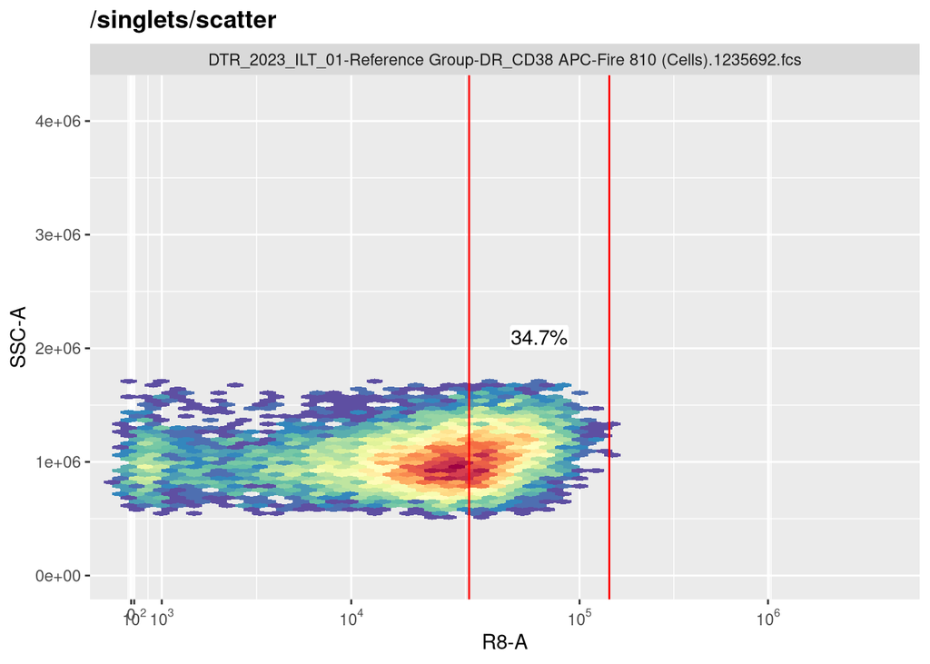

```r
autoplot(APCFire810_GS, "APCFire810")
```

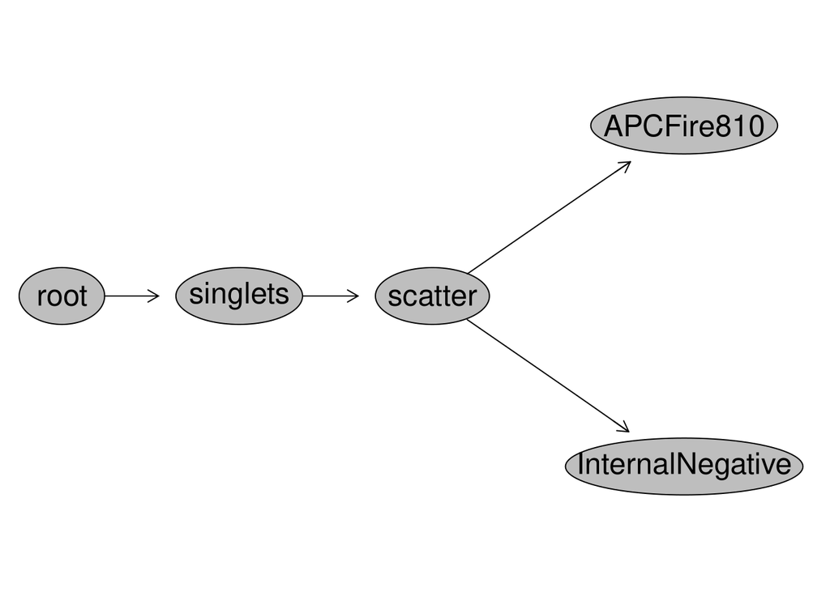

```r
plot(APCFire810_GS)
```

## Modified gating

```r
APCFire810_filename2 <- file.path(result_path, "APCFire810_2.gs")
if (! file.exists(APCFire810_filename2) || recompute) {
  APCFire810_GS2 <- flowWorkspace::gs_copy_tree_only(APCFire810_GS)
  gs_apply_gate_check(gs=APCFire810_GS2, gate="APCFire810")
  plot(APCFire810_GS2)
  save_gs(APCFire810_GS2, APCFire810_filename2, backend_opt = "copy")
} else {
  APCFire810_GS2 <- load_gs(APCFire810_filename2)
}
```

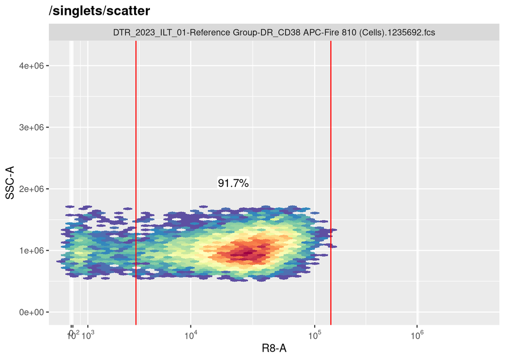

```r
autoplot(APCFire810_GS2, "APCFire810")
```

I’m not sure if I understood this correctly. Maybe I should have included even those cells that are in the internal negatives as positives?

## Positive data

```r
PositiveCytoSet <- gs_pop_get_data(APCFire810_GS, "APCFire810", inverse.transform=TRUE)
PositiveData <- exprs(PositiveCytoSet[[1]]) %>%
  data.frame(check.names=FALSE)
head(PositiveData, 3)
```

| Time | UV1-A | UV2-A | UV3-A | UV4-A | UV5-A | UV6-A | UV7-A | UV8-A | UV9-A | UV10-A | UV11-A | UV12-A | UV13-A | UV14-A | UV15-A | UV16-A | SSC-W | SSC-H | SSC-A | V1-A | V2-A | V3-A | V4-A | V5-A | V6-A | V7-A | V8-A | V9-A | V10-A | … |
| --- | --- | --- | --- | --- | --- | --- | --- | --- | --- | --- | --- | --- | --- | --- | --- | --- | --- | --- | --- | --- | --- | --- | --- | --- | --- | --- | --- | --- | --- | --- |
| 521939 | 641.7078 | 589.1987 | 1074.3470 | 1058.2816 | 1032.845 | 1901.992 | 4073.742 | 2631.536 | 2337.457 | 991.6415 | 3273.9131 | 2324.6646 | 1510.7793 | 1719.4755 | 2032.8173 | 7380.604 | 670261.9 | 1023604 | 1143471 | 851.1250 | 3566.819 | 4903.525 | 5478.481 | 7382.444 | 6454.525 | 8553.464 | 6269.176 | 4711.025 | 5532.175 | … |
| 18412 | 153.5099 | 139.0814 | 691.3152 | 402.6661 | 1014.623 | 1298.513 | 2765.412 | 2353.597 | 2220.689 | 996.1790 | 2417.4846 | 1383.9696 | 1036.8619 | 1292.1914 | 1789.8342 | 5465.298 | 687311.4 | 1050826 | 1203741 | 427.4191 | 1557.737 | 2713.356 | 3466.100 | 4781.082 | 5320.149 | 6556.961 | 5045.149 | 4408.387 | 5030.369 | … |
| 164186 | 116.5459 | 720.0988 | 269.3858 | 567.9276 | 1149.465 | 1488.170 | 3432.184 | 2119.241 | 1511.151 | 761.6002 | 817.3074 | 991.9396 | 180.2108 | 497.0484 | 759.1456 | 3629.500 | 639144.4 | 1002897 | 1068327 | 448.1815 | 2087.387 | 3081.719 | 3676.131 | 4396.150 | 4661.457 | 6704.844 | 4425.645 | 3920.676 | 4792.631 | … |

Modified version of the positive gate.

```r
PositiveCytoSet2 <- gs_pop_get_data(APCFire810_GS2, "APCFire810", inverse.transform=TRUE)
PositiveData2 <- exprs(PositiveCytoSet2[[1]]) %>%
  data.frame(check.names=FALSE)
head(PositiveData2, 3)
```

| Time | UV1-A | UV2-A | UV3-A | UV4-A | UV5-A | UV6-A | UV7-A | UV8-A | UV9-A | UV10-A | UV11-A | UV12-A | UV13-A | UV14-A | UV15-A | UV16-A | SSC-W | SSC-H | SSC-A | V1-A | V2-A | V3-A | V4-A | V5-A | V6-A | V7-A | V8-A | V9-A | V10-A | … |
| --- | --- | --- | --- | --- | --- | --- | --- | --- | --- | --- | --- | --- | --- | --- | --- | --- | --- | --- | --- | --- | --- | --- | --- | --- | --- | --- | --- | --- | --- | --- |
| 128842 | 946.8678 | 554.6889 | 257.4122 | 176.8642 | 1036.8619 | 731.4785 | 2418.898 | 1520.151 | 1421.976 | 403.6333 | 1127.525 | 271.0222 | 587.6367 | 654.12866 | 906.5570 | 2892.146 | 665252.0 | 734706 | 814607.7 | 806.3693 | 1520.543 | 1895.231 | 2869.488 | 3315.262 | 3337.607 | 5028.100 | 3843.744 | 2923.731 | 3628.694 | … |
| 36641 | 454.3564 | 467.7440 | 805.4073 | 637.8396 | 749.5511 | 933.0344 | 2755.742 | 1971.532 | 2101.317 | 983.7585 | 1622.938 | 603.2559 | 995.5835 | 84.34143 | 388.6096 | 1968.632 | 653858.7 | 729136 | 794586.5 | 698.5687 | 1796.712 | 3030.432 | 2978.938 | 4188.457 | 4255.694 | 5965.025 | 5261.437 | 2784.237 | 3443.344 | … |
| 163817 | 433.6066 | 876.9561 | 352.4630 | 380.6509 | 955.7930 | 1805.0073 | 2728.298 | 1963.351 | 1763.283 | 857.7669 | 1261.251 | 814.4811 | 765.5416 | 668.78015 | 1032.1760 | 2038.917 | 644424.6 | 751573 | 807220.1 | 468.3935 | 1657.907 | 2515.013 | 2772.275 | 4502.575 | 4504.088 | 6668.200 | 4584.044 | 3775.887 | 4350.569 | … |

```r
summary(PositiveData)
```

```
      Time            UV1-A            UV2-A            UV3-A
 Min.   :    84   Min.   :-833.6   Min.   :-567.0   Min.   :-617.2
 1st Qu.:147590   1st Qu.: 115.7   1st Qu.: 416.9   1st Qu.: 382.8
 Median :286090   Median : 340.9   Median : 656.6   Median : 599.2
 Mean   :292365   Mean   : 348.4   Mean   : 664.5   Mean   : 597.3
 3rd Qu.:435098   3rd Qu.: 582.5   3rd Qu.: 900.0   3rd Qu.: 813.0
 Max.   :603617   Max.   :1736.8   Max.   :1918.7   Max.   :1687.0
     UV4-A            UV5-A            UV6-A            UV7-A
 Min.   :-321.8   Min.   :-101.4   Min.   : 203.6   Min.   :1122
 1st Qu.: 485.1   1st Qu.: 795.6   1st Qu.:1366.8   1st Qu.:2780
 Median : 713.9   Median :1022.8   Median :1684.7   Median :3299
 Mean   : 718.3   Mean   :1032.5   Mean   :1679.4   Mean   :3296
 3rd Qu.: 947.9   3rd Qu.:1265.9   3rd Qu.:1979.9   3rd Qu.:3798
 Max.   :2079.1   Max.   :2506.0   Max.   :3298.2   Max.   :6186
     UV8-A            UV9-A            UV10-A           UV11-A
 Min.   : 513.8   Min.   : 572.5   Min.   :-484.1   Min.   : 198.9
 1st Qu.:2080.7   1st Qu.:1876.5   1st Qu.: 740.3   1st Qu.:1557.7
 Median :2436.1   Median :2280.8   Median : 987.3   Median :1960.0
 Mean   :2439.7   Mean   :2286.4   Mean   : 988.5   Mean   :2088.2
 3rd Qu.:2809.1   3rd Qu.:2658.1   3rd Qu.:1232.2   3rd Qu.:2490.8
 Max.   :4404.7   Max.   :4355.3   Max.   :2167.7   Max.   :8012.7
     UV12-A           UV13-A           UV14-A           UV15-A
 Min.   :-392.0   Min.   :-370.3   Min.   :-334.7   Min.   : -85.46
 1st Qu.: 760.3   1st Qu.: 645.5   1st Qu.: 765.5   1st Qu.:1063.41
 Median :1030.4   Median : 901.1   Median :1055.4   Median :1374.08
 Mean   :1065.9   Mean   : 946.3   Mean   :1089.6   Mean   :1434.91
 3rd Qu.:1329.3   3rd Qu.:1207.9   3rd Qu.:1378.1   3rd Qu.:1721.11
 Max.   :3484.7   Max.   :3073.7   Max.   :4076.9   Max.   :4091.89
     UV16-A          SSC-W             SSC-H             SSC-A
 Min.   : 1733   Min.   : 607182   Min.   : 449888   Min.   : 532112
 1st Qu.: 3426   1st Qu.: 662062   1st Qu.: 819002   1st Qu.: 929892
 Median : 4070   Median : 676580   Median : 951043   Median :1081074
 Mean   : 4442   Mean   : 684690   Mean   : 953519   Mean   :1087766
 3rd Qu.: 5111   3rd Qu.: 693162   3rd Qu.:1076276   3rd Qu.:1234102
 Max.   :14054   Max.   :1142573   Max.   :1533111   Max.   :1710405
      V1-A             V2-A             V3-A           V4-A
 Min.   :-366.5   Min.   : 628.4   Min.   :1274   Min.   :1257
 1st Qu.: 414.8   1st Qu.:1797.9   1st Qu.:2986   1st Qu.:3371
 Median : 629.3   Median :2186.9   Median :3621   Median :4044
 Mean   : 629.4   Mean   :2188.7   Mean   :3647   Mean   :4091
```

[output cut: 78 more lines]

```
 Max.   :40796   Max.   :93836   Max.   :88220   Max.   :65785
      R4-A            R5-A            R6-A            R7-A
 Min.   : 2245   Min.   : 1695   Min.   : 1868   Min.   :10811
 1st Qu.: 8755   1st Qu.: 7272   1st Qu.: 5471   1st Qu.:14938
 Median :11295   Median : 9551   Median : 7115   Median :17770
 Mean   :12573   Mean   :10684   Mean   : 7898   Mean   :19675
 3rd Qu.:14986   3rd Qu.:12861   3rd Qu.: 9452   3rd Qu.:22718
 Max.   :54530   Max.   :49047   Max.   :35646   Max.   :60396
      R8-A
 Min.   : 29636
 1st Qu.: 34294
 Median : 40904
 Mean   : 45786
 3rd Qu.: 52670
 Max.   :142127
```

## Negative data

```r
NegativeCytoSet <- gs_pop_get_data(APCFire810_GS, "InternalNegative", inverse.transform=TRUE)
NegativeData <- exprs(NegativeCytoSet[[1]]) %>% #[[1]] used to remove list item, allowing access
  data.frame(check.names=FALSE)
head(NegativeData, 3)
```

| Time | UV1-A | UV2-A | UV3-A | UV4-A | UV5-A | UV6-A | UV7-A | UV8-A | UV9-A | UV10-A | UV11-A | UV12-A | UV13-A | UV14-A | UV15-A | UV16-A | SSC-W | SSC-H | SSC-A | V1-A | V2-A | V3-A | V4-A | V5-A | V6-A | V7-A | V8-A | V9-A | V10-A | … |
| --- | --- | --- | --- | --- | --- | --- | --- | --- | --- | --- | --- | --- | --- | --- | --- | --- | --- | --- | --- | --- | --- | --- | --- | --- | --- | --- | --- | --- | --- | --- |
| 37476 | 574.69519 | 721.9586 | 761.0048 | 820.43085 | 1209.1887 | 1728.624 | 3326.348 | 2116.043 | 2448.722 | 621.0314 | 646.9134 | 205.5729 | 133.9492 | 525.7569 | 454.4310 | 262.9158 | 660806.4 | 1016762 | 1119804.9 | 948.0623 | 2050.882 | 4383.913 | 4227.781 | 5319.738 | 4942.025 | 7542.495 | 5047.007 | 4334.894 | 4705.388 | … |
| 179720 | 67.90479 | 562.3496 | 232.1990 | 1347.89868 | 1019.5323 | 1815.642 | 2997.387 | 1916.421 | 2149.511 | 916.3739 | 765.4676 | 707.6783 | 403.1870 | 618.1310 | 347.4803 | 152.8411 | 653952.9 | 560464 | 610861.8 | 649.8937 | 1573.413 | 2951.643 | 3583.800 | 5462.600 | 5052.575 | 7003.700 | 5157.969 | 3729.619 | 3827.519 | … |
| 378517 | 216.28224 | 279.7248 | 1199.9666 | -74.44981 | 800.9441 | 1503.639 | 3320.100 | 2662.997 | 2372.414 | 621.7749 | 659.5576 | 257.1888 | 558.3334 | 361.4630 | -177.8309 | 169.9469 | 704944.6 | 799284 | 939084.8 | 386.0315 | 2380.675 | 3552.518 | 3858.869 | 5861.213 | 5718.350 | 7996.657 | 5301.725 | 4099.494 | 5365.250 | … |

```r
summary(NegativeData)
```

```
      Time            UV1-A            UV2-A            UV3-A
 Min.   :   603   Min.   :-781.3   Min.   :-530.3   Min.   :-243.8
 1st Qu.:156999   1st Qu.: 113.7   1st Qu.: 374.1   1st Qu.: 361.9
 Median :303637   Median : 300.0   Median : 618.4   Median : 595.1
 Mean   :302992   Mean   : 328.2   Mean   : 632.4   Mean   : 596.2
 3rd Qu.:457586   3rd Qu.: 537.4   3rd Qu.: 888.7   3rd Qu.: 807.8
 Max.   :601230   Max.   :1299.7   Max.   :2197.8   Max.   :1782.3
     UV4-A            UV5-A            UV6-A            UV7-A
 Min.   :-229.4   Min.   :-165.9   Min.   : 364.5   Min.   :1088
 1st Qu.: 485.3   1st Qu.: 737.9   1st Qu.:1306.8   1st Qu.:2608
 Median : 670.0   Median : 976.6   Median :1565.1   Median :3051
 Mean   : 695.9   Mean   :1001.1   Mean   :1604.6   Mean   :3128
 3rd Qu.: 919.0   3rd Qu.:1229.3   3rd Qu.:1822.0   3rd Qu.:3471
 Max.   :2375.4   Max.   :2690.6   Max.   :5144.8   Max.   :9015
     UV8-A          UV9-A            UV10-A           UV11-A
 Min.   : 740   Min.   : 617.8   Min.   :-142.0   Min.   :-160.7
 1st Qu.:1974   1st Qu.:1792.7   1st Qu.: 642.5   1st Qu.: 458.5
 Median :2271   Median :2109.3   Median : 918.5   Median : 659.6
 Mean   :2333   Mean   :2168.8   Mean   : 919.2   Mean   : 676.4
 3rd Qu.:2625   3rd Qu.:2494.0   3rd Qu.:1162.9   3rd Qu.: 889.0
 Max.   :6432   Max.   :6036.7   Max.   :2548.9   Max.   :1849.3
     UV12-A           UV13-A           UV14-A           UV15-A
 Min.   :-405.7   Min.   :-484.2   Min.   :-470.0   Min.   :-571.8
 1st Qu.: 256.9   1st Qu.: 133.9   1st Qu.: 185.3   1st Qu.: 104.5
 Median : 436.9   Median : 330.7   Median : 416.6   Median : 307.6
 Mean   : 434.5   Mean   : 324.7   Mean   : 414.2   Mean   : 312.8
 3rd Qu.: 613.9   3rd Qu.: 517.9   3rd Qu.: 620.8   3rd Qu.: 514.2
 Max.   :1397.7   Max.   :1351.4   Max.   :1337.3   Max.   :1438.1
     UV16-A            SSC-W             SSC-H             SSC-A
 Min.   :-750.82   Min.   : 626198   Min.   : 471628   Min.   : 537994
 1st Qu.:  70.88   1st Qu.: 660218   1st Qu.: 749807   1st Qu.: 846160
 Median : 310.74   Median : 677348   Median : 861833   Median : 978721
 Mean   : 304.67   Mean   : 693720   Mean   : 872906   Mean   :1009663
 3rd Qu.: 541.45   3rd Qu.: 707285   3rd Qu.: 988373   3rd Qu.:1155090
 Max.   :1137.49   Max.   :1057562   Max.   :1460101   Max.   :1705649
      V1-A             V2-A              V3-A            V4-A
 Min.   :-397.6   Min.   :  751.4   Min.   : 1561   Min.   : 1741
 1st Qu.: 427.5   1st Qu.: 1720.7   1st Qu.: 2896   1st Qu.: 3223
 Median : 611.5   Median : 2056.1   Median : 3350   Median : 3758
 Mean   : 624.7   Mean   : 2162.7   Mean   : 3537   Mean   : 3974
```

[output cut: 78 more lines]

```
 Max.   :1301.3   Max.   :2873.8   Max.   :2614.9   Max.   :2319.5
      R4-A             R5-A             R6-A             R7-A
 Min.   :-189.5   Min.   :-550.9   Min.   :-466.3   Min.   :-561.3
 1st Qu.: 426.2   1st Qu.: 271.8   1st Qu.: 142.9   1st Qu.: 188.7
 Median : 666.1   Median : 508.6   Median : 347.1   Median : 477.3
 Mean   : 685.7   Mean   : 496.8   Mean   : 365.2   Mean   : 466.4
 3rd Qu.: 892.4   3rd Qu.: 724.4   3rd Qu.: 573.0   3rd Qu.: 708.2
 Max.   :2254.6   Max.   :1552.6   Max.   :1681.0   Max.   :1744.2
      R8-A
 Min.   :-425.6
 1st Qu.: 266.8
 Median : 574.7
 Mean   : 584.3
 3rd Qu.: 915.9
 Max.   :1588.0
```

## Signatures

```r
# SFC_Parameters <- colnames(PositiveData)
# PositiveDataSignature <- PositiveData[!stringr::str_detect(colnames(PositiveData), "FSC|SSC|Time")]
PositiveDataSignature <- PositiveData %>% select(!matches("FSC|SSC|Time"))
PositiveDataSignature2 <- PositiveData2 %>% select(!matches("FSC|SSC|Time"))
head(PositiveDataSignature, 3)
```

| UV1-A | UV2-A | UV3-A | UV4-A | UV5-A | UV6-A | UV7-A | UV8-A | UV9-A | UV10-A | UV11-A | UV12-A | UV13-A | UV14-A | UV15-A | UV16-A | V1-A | V2-A | V3-A | V4-A | V5-A | V6-A | V7-A | V8-A | V9-A | V10-A | V11-A | V12-A | V13-A | V14-A | … |
| --- | --- | --- | --- | --- | --- | --- | --- | --- | --- | --- | --- | --- | --- | --- | --- | --- | --- | --- | --- | --- | --- | --- | --- | --- | --- | --- | --- | --- | --- | --- |
| 641.7078 | 589.1987 | 1074.3470 | 1058.2816 | 1032.845 | 1901.992 | 4073.742 | 2631.536 | 2337.457 | 991.6415 | 3273.9131 | 2324.6646 | 1510.7793 | 1719.4755 | 2032.8173 | 7380.604 | 851.1250 | 3566.819 | 4903.525 | 5478.481 | 7382.444 | 6454.525 | 8553.464 | 6269.176 | 4711.025 | 5532.175 | 11721.944 | 5689.200 | 4920.988 | 4275.219 | … |
| 153.5099 | 139.0814 | 691.3152 | 402.6661 | 1014.623 | 1298.513 | 2765.412 | 2353.597 | 2220.689 | 996.1790 | 2417.4846 | 1383.9696 | 1036.8619 | 1292.1914 | 1789.8342 | 5465.298 | 427.4191 | 1557.737 | 2713.356 | 3466.100 | 4781.082 | 5320.149 | 6556.961 | 5045.149 | 4408.387 | 5030.369 | 7062.138 | 3361.256 | 3707.756 | 2138.262 | … |
| 116.5459 | 720.0988 | 269.3858 | 567.9276 | 1149.465 | 1488.170 | 3432.184 | 2119.241 | 1511.151 | 761.6002 | 817.3074 | 991.9396 | 180.2108 | 497.0484 | 759.1456 | 3629.500 | 448.1815 | 2087.387 | 3081.719 | 3676.131 | 4396.150 | 4661.457 | 6704.844 | 4425.645 | 3920.676 | 4792.631 | 4639.732 | 2316.875 | 2186.800 | 2023.725 | … |

```r
#NegativeDataSignature <- NegativeData[!stringr::str_detect(colnames(NegativeData), "FSC|SSC|Time")]
NegativeDataSignature <- NegativeData %>% select(!matches("FSC|SSC|Time"))

head(NegativeDataSignature, 3)
```

| UV1-A | UV2-A | UV3-A | UV4-A | UV5-A | UV6-A | UV7-A | UV8-A | UV9-A | UV10-A | UV11-A | UV12-A | UV13-A | UV14-A | UV15-A | UV16-A | V1-A | V2-A | V3-A | V4-A | V5-A | V6-A | V7-A | V8-A | V9-A | V10-A | V11-A | V12-A | V13-A | V14-A | … |
| --- | --- | --- | --- | --- | --- | --- | --- | --- | --- | --- | --- | --- | --- | --- | --- | --- | --- | --- | --- | --- | --- | --- | --- | --- | --- | --- | --- | --- | --- | --- |
| 574.69519 | 721.9586 | 761.0048 | 820.43085 | 1209.1887 | 1728.624 | 3326.348 | 2116.043 | 2448.722 | 621.0314 | 646.9134 | 205.5729 | 133.9492 | 525.7569 | 454.4310 | 262.9158 | 948.0623 | 2050.882 | 4383.913 | 4227.781 | 5319.738 | 4942.025 | 7542.495 | 5047.007 | 4334.894 | 4705.388 | 2797.781 | 1410.338 | 1426.356 | 1067.2067 | … |
| 67.90479 | 562.3496 | 232.1990 | 1347.89868 | 1019.5323 | 1815.642 | 2997.387 | 1916.421 | 2149.511 | 916.3739 | 765.4676 | 707.6783 | 403.1870 | 618.1310 | 347.4803 | 152.8411 | 649.8937 | 1573.413 | 2951.643 | 3583.800 | 5462.600 | 5052.575 | 7003.700 | 5157.969 | 3729.619 | 3827.519 | 2675.957 | 1048.850 | 1113.956 | 1035.7190 | … |
| 216.28224 | 279.7248 | 1199.9666 | -74.44981 | 800.9441 | 1503.639 | 3320.100 | 2662.997 | 2372.414 | 621.7749 | 659.5576 | 257.1888 | 558.3334 | 361.4630 | -177.8309 | 169.9469 | 386.0315 | 2380.675 | 3552.518 | 3858.869 | 5861.213 | 5718.350 | 7996.657 | 5301.725 | 4099.494 | 5365.250 | 2539.694 | 1778.150 | 1532.231 | 939.8808 | … |

```r
PositiveSignature <- PositiveDataSignature |> summarize_all("median") #Alternate: "mean"
PositiveSignature
```

| UV1-A | UV2-A | UV3-A | UV4-A | UV5-A | UV6-A | UV7-A | UV8-A | UV9-A | UV10-A | UV11-A | UV12-A | UV13-A | UV14-A | UV15-A | UV16-A | V1-A | V2-A | V3-A | V4-A | V5-A | V6-A | V7-A | V8-A | V9-A | V10-A | V11-A | V12-A | V13-A | V14-A | … |
| --- | --- | --- | --- | --- | --- | --- | --- | --- | --- | --- | --- | --- | --- | --- | --- | --- | --- | --- | --- | --- | --- | --- | --- | --- | --- | --- | --- | --- | --- | --- |
| 340.8606 | 656.5828 | 599.2394 | 713.9257 | 1022.805 | 1684.743 | 3298.681 | 2436.079 | 2280.784 | 987.3284 | 1960.005 | 1030.391 | 901.0533 | 1055.381 | 1374.078 | 4069.577 | 629.3373 | 2186.869 | 3621.132 | 4044.15 | 5891.669 | 5565.381 | 7681.093 | 5828.419 | 4136.825 | 4876.025 | 6319.981 | 3103.718 | 2941.056 | 2496.175 | … |

```r
PositiveSignature2 <- PositiveDataSignature2 |> summarize_all("median") #Alternate: "mean"
PositiveSignature2
```

| UV1-A | UV2-A | UV3-A | UV4-A | UV5-A | UV6-A | UV7-A | UV8-A | UV9-A | UV10-A | UV11-A | UV12-A | UV13-A | UV14-A | UV15-A | UV16-A | V1-A | V2-A | V3-A | V4-A | V5-A | V6-A | V7-A | V8-A | V9-A | V10-A | V11-A | V12-A | V13-A | V14-A | … |
| --- | --- | --- | --- | --- | --- | --- | --- | --- | --- | --- | --- | --- | --- | --- | --- | --- | --- | --- | --- | --- | --- | --- | --- | --- | --- | --- | --- | --- | --- | --- |
| 322.2299 | 616.2714 | 555.4696 | 669.7466 | 961.5204 | 1553.954 | 3068.601 | 2302.687 | 2147.429 | 926.3033 | 1440.83 | 778.1483 | 681.6099 | 791.201 | 942.3688 | 2493.125 | 584.0659 | 2018.362 | 3317.91 | 3748.112 | 5480.372 | 5194.75 | 7234.115 | 5501.375 | 3903.832 | 4567.957 | 4711.128 | 2388.994 | 2230.765 | 1934.282 | … |

```r
NegativeSignature <- NegativeDataSignature |> summarize_all("median") #Alternate: "mean"
NegativeSignature
```

| UV1-A | UV2-A | UV3-A | UV4-A | UV5-A | UV6-A | UV7-A | UV8-A | UV9-A | UV10-A | UV11-A | UV12-A | UV13-A | UV14-A | UV15-A | UV16-A | V1-A | V2-A | V3-A | V4-A | V5-A | V6-A | V7-A | V8-A | V9-A | V10-A | V11-A | V12-A | V13-A | V14-A | … |
| --- | --- | --- | --- | --- | --- | --- | --- | --- | --- | --- | --- | --- | --- | --- | --- | --- | --- | --- | --- | --- | --- | --- | --- | --- | --- | --- | --- | --- | --- | --- |
| 300.0285 | 618.4281 | 595.1484 | 670.0449 | 976.6178 | 1565.073 | 3050.789 | 2271.338 | 2109.35 | 918.5318 | 659.5576 | 436.879 | 330.7455 | 416.5743 | 307.6154 | 310.7392 | 611.4629 | 2056.107 | 3349.637 | 3758.15 | 5517.6 | 5187.325 | 7236.281 | 5496.631 | 3892.625 | 4463.594 | 2573.588 | 1458.462 | 1332.031 | 1164.693 | … |

Visualize both versions of the positive data.

```r
PositivePlotData <- PositiveSignature |> mutate(Fluorophore="APCFire810") |> relocate(Fluorophore, .before=1)
PositivePlotData2 <- PositiveSignature2 |> mutate(Fluorophore="APCFire810_modified") |> relocate(Fluorophore, .before=1)

BothPositives <- bind_rows(PositivePlotData, PositivePlotData2)
Plots <- VisualizeSignatures(data=BothPositives, columnname="Fluorophore", Normalize = FALSE)
plotly::ggplotly(Plots)
```

[interactive chart not shown]

The signal seems to be weaker in the modified GatingSet.

```r
NegativePlotData <- NegativeSignature |> mutate(Fluorophore="Background") |> relocate(Fluorophore, .before=1)

Plots <- VisualizeSignatures(data=NegativePlotData, columnname="Fluorophore", Normalize = FALSE)
plotly::ggplotly(Plots)
```

[interactive chart not shown]

Peaks at UV7, V7 and B3. This is apperently typical for autofluorescence.

```r
Outputs <- QC_WhatsThis(x="APCFire810", columnname="Fluorophore", data=PositivePlotData, NumberDetectors = 64,
 returnPlots=TRUE, NumberHits = 5)
```

```
Normalizing Data for Signature Comparison
```

```r
Outputs[[1]]
```

| Fluorophore | ID_APCFire810 |
| --- | --- |
| cFluor R840 | 0.82 |
| APC-Astral 813 | 0.80 |
| APC-Fire 810 | 0.80 |
| DyLight 800 | 0.75 |
| CF770 | 0.72 |

```r
plotly::ggplotly(Outputs[[2]])
```

[interactive chart not shown]

## Subtraction of background

```r
# dim(PositiveSignature) == dim(NegativeSignature)
# str(PositiveSignature)
JustTheFluorophore <- PositiveSignature - NegativeSignature
JustTheFluorophore2 <- PositiveSignature2 - NegativeSignature
JustTheFluorophore
```

| UV1-A | UV2-A | UV3-A | UV4-A | UV5-A | UV6-A | UV7-A | UV8-A | UV9-A | UV10-A | UV11-A | UV12-A | UV13-A | UV14-A | UV15-A | UV16-A | V1-A | V2-A | V3-A | V4-A | V5-A | V6-A | V7-A | V8-A | V9-A | V10-A | V11-A | V12-A | V13-A | V14-A | … |
| --- | --- | --- | --- | --- | --- | --- | --- | --- | --- | --- | --- | --- | --- | --- | --- | --- | --- | --- | --- | --- | --- | --- | --- | --- | --- | --- | --- | --- | --- | --- |
| 40.83212 | 38.15472 | 4.090942 | 43.88074 | 46.18707 | 119.6694 | 247.8918 | 164.7407 | 171.4343 | 68.79657 | 1300.447 | 593.5121 | 570.3078 | 638.8068 | 1066.463 | 3758.838 | 17.87439 | 130.7622 | 271.4949 | 285.9998 | 374.0693 | 378.0557 | 444.8125 | 331.7886 | 244.1997 | 412.4312 | 3746.393 | 1645.256 | 1609.025 | 1331.481 | … |

## Plot

```r
JustTheFluorophorePlot <- JustTheFluorophore |>
   mutate(Fluorophore="APCFire810", .before=1)
JustTheFluorophorePlot2 <- JustTheFluorophore2 |>
   mutate(Fluorophore="APCFire810_modified", .before=1)

# Intermediate <- PositiveSignature |>
#    mutate(Fluorophore="Alexa_Pre", .before=1)

JustTheFluorophorePlot_both <- bind_rows(JustTheFluorophorePlot, JustTheFluorophorePlot2)
```

### Unnormalised

```r
Plots <- VisualizeSignatures(data=JustTheFluorophorePlot_both,
 columnname="Fluorophore", Normalize = FALSE)

plotly::ggplotly(Plots)
```

[interactive chart not shown]

### Normalised

```r
Plots <- VisualizeSignatures(data=JustTheFluorophorePlot_both,
 columnname="Fluorophore", Normalize = TRUE)
```

```
Normalizing Data for Signature Comparison
```

```r
plotly::ggplotly(Plots)
```

[interactive chart not shown]

Looks identical.

# Problem 3

> An important part of retrieving the fluorescent signature is to subtract the background autofluorescence. This could vary based on donor, cell type or treatment condition. With the tools provided in this walkthrough, compare the autofluorescent signatures for the 3 cell unstained controls, and whether their use as background would have affected the overall APC-Fire 810 extracted signature or not.

Form external negative based on each unstained sample.

## Negative signatures

```r
get_external_negative_signature <- function(gs) {
  ExternalNegativeCytoSet <- gs_pop_get_data(gs[1], "scatter", inverse.transform=TRUE)
  ExternalNegativeData <- exprs(ExternalNegativeCytoSet[[1]]) %>% #[[1]] used to remove list item, allowing access
    data.frame(check.names=FALSE)
  ExternalNegativeSignature <- ExternalNegativeData %>%
    select(!matches("FSC|SSC|Time")) |>
    summarize_all("median")
}
ExternalNegativeSignature1 <- get_external_negative_signature(CellsUnstained_GatingSet[1])
ExternalNegativeSignature2 <- get_external_negative_signature(CellsUnstained_GatingSet[2])
ExternalNegativeSignature3 <- get_external_negative_signature(CellsUnstained_GatingSet[3])
ExternalNegativePlotData1 <- ExternalNegativeSignature1 |>
   mutate(Fluorophore="ExternalBackground1", .before=1)
ExternalNegativePlotData2 <- ExternalNegativeSignature2 |>
   mutate(Fluorophore="ExternalBackground2", .before=1)
ExternalNegativePlotData3 <- ExternalNegativeSignature3 |>
   mutate(Fluorophore="ExternalBackground3", .before=1)
```

Compare the signatures.

```r
CombinedAutofluorescences <- bind_rows(
  ExternalNegativePlotData1,
  ExternalNegativePlotData2,
  ExternalNegativePlotData3)

Plots <- VisualizeSignatures(data=CombinedAutofluorescences,
 columnname="Fluorophore", Normalize = FALSE)

plotly::ggplotly(Plots)
```

[interactive chart not shown]

Normalised version.

```r
Plots <- VisualizeSignatures(data=CombinedAutofluorescences,
 columnname="Fluorophore", Normalize = TRUE)
```

```
Normalizing Data for Signature Comparison
```

```r
plotly::ggplotly(Plots)
```

[interactive chart not shown]

The three unstained samples seem to have quite similar autofluorescences.

## Remove background

```r
JustTheFluorophore1 <- PositiveSignature - ExternalNegativeSignature1
JustTheFluorophore2 <- PositiveSignature - ExternalNegativeSignature2
JustTheFluorophore3 <- PositiveSignature - ExternalNegativeSignature3
JustTheFluorophorePlot1 <- JustTheFluorophore1 |>
   mutate(Fluorophore="APCFire810_1", .before=1)
JustTheFluorophorePlot2 <- JustTheFluorophore2 |>
   mutate(Fluorophore="APCFire810_2", .before=1)
JustTheFluorophorePlot3 <- JustTheFluorophore3 |>
   mutate(Fluorophore="APCFire810_3", .before=1)


JustTheFluorophorePlot <- bind_rows(
  JustTheFluorophorePlot1,
  JustTheFluorophorePlot2,
  JustTheFluorophorePlot3)

Plots <- VisualizeSignatures(data=JustTheFluorophorePlot,
 columnname="Fluorophore", Normalize = FALSE)

plotly::ggplotly(Plots)
```

[interactive chart not shown]

Normalize.

```r
Plots <- VisualizeSignatures(data=JustTheFluorophorePlot,
 columnname="Fluorophore", Normalize = TRUE)
```

```
Normalizing Data for Signature Comparison
```

```r
plotly::ggplotly(Plots)
```

[interactive chart not shown]

No difference in the subtracted signal no matter which of the background samples are used.